# **Telecom Data Analysis Project to Improve Service Quality**

# **Business Overview**

The telecommunications industry is a rapidly growing sector that is constantly evolving to meet the demands of consumers. As technology advances and user behavior changes, telecom operators face a variety of challenges that can impact their business success. In order to stay competitive and meet customer needs, it is important for telecom companies to regularly analyze their data to identify relevant problems and opportunities for improvement.

The aim of this project is to explore the telecom data and find relevant problems faced by telecom operators. By conducting an exploratory data analysis (EDA) on a large volume of telecom data, we can gain valuable insights into user behavior, network performance, customer demographics, and more. Through this analysis, we hope to identify potential areas for improvement, such as improving customer satisfaction, optimizing network performance and increasing revenue through targeted marketing efforts.

The insights gained from this project can help telecom operators make informed decisions about their business strategy, enabling them to better meet the needs of their customers and stay competitive in the market.

[figure not shown]

## **Approach**

- Univariate Data Analysis:
  - Create histograms to visualize the distribution of the variables related to the hypotheses.
  - Use countplots to compare the frequencies of different categorical variables with respect to the hypotheses.
  - Create box plots to visualize the median, quartiles, and outliers of the continuous variables with respect to the hypotheses.
- Bivariate Data Analysis:
  - Create scatter plots to investigate the relationship between two continuous variables related to the hypotheses.
  - Create box plots to compare the distributions of the continuous variables with respect to the categorical variables related to the hypotheses.
  - Chi-Square Test and ANOVA:
    - Perform the chi-square test to evaluate the relationship between two categorical variables related to the hypotheses.
    - Use ANOVA to evaluate the difference in means between two or more groups related to the hypotheses.
- Multivariate Data Analysis:
  - Use correlation analysis to investigate the strength and direction of the relationship between multiple continuous variables related to the hypotheses.
- Project Summary:
  - Analyze the results obtained from the above tests to draw conclusions about the hypotheses.
  - Provide recommendations to improve customer satisfaction and retention based on the findings.

## **Learning Outcomes**

- Apply univariate data analysis techniques such as histograms, countplots, and box plots to visualize and explore the distribution of variables related to the hypotheses.
- Use bivariate data analysis techniques such as scatter plots and box plots to investigate the relationship between two continuous variables or compare the distribution of continuous variables with respect to categorical variables related to the hypotheses.
- Perform statistical tests such as chi-square and ANOVA to evaluate the relationship between two categorical variables or differences in means between groups related to the hypotheses.
- Apply multivariate data analysis techniques such as correlation analysis to investigate the strength and direction of the relationship between multiple continuous variables related to the hypotheses.
- Draw conclusions and provide recommendations based on the findings of the analysis to improve customer satisfaction and retention.
- Understand the importance of data analysis in making informed business decisions and its applications in the telecommunications industry.
- Develop critical thinking and problem-solving skills by analyzing complex data sets and identifying patterns and trends to support business decision-making.
- Improve data visualization skills by creating effective visual representations of data using different techniques and tools.
- Enhance your statistical analysis skills by applying statistical tests and techniques to evaluate hypotheses and draw conclusions based on the results.

## **Prerequisites**

- Familiarity with Python programming language
- Familiarity with Pandas, sklearn, numpy libraries in Python, along with concepts like loops, lists, arrays and dataframe.
- You should have a fundamental understanding of data analysis techniques and their applications in solving business problems. This includes descriptive statistics, data visualization, and statistical inference.

## **Execution Instructions**

**Click here to view more**

### **Installation and Setup for IPYNB**

For the best experience, please stay connected to the internet while executing this Project

#### **Running an IPYNB on Google Colab**:

- Open the [Google Colab website](https://colab.research.google.com/).
- Click on the "New Notebook" button.
- Click the "File" menu in the new notebook and choose "Upload notebook."
- Select the IPYNB file(notebooks/telco_data_analysis.ipynb) you want to upload.
- Once the file is uploaded, click on the "Runtime" menu and choose "Run all" to execute all the cells in the notebook.
- Alternatively, you can execute each cell individually by clicking the "Play" button next to the cell OR by pressing `"shift” + "enter"`.
- The Default version of Python that Colab uses currently is 3.8

#### **Python setup steps for Local Machine**:

- If you're using a local machine and do not have Python installed, follow these steps to set up Python:
- Download and install the latest version of Python from the official Python website: https://www.python.org/downloads/.
- Once the installation is complete, open a command prompt/terminal and type the following command to check if Python is installed `python –-version`
- If Python is installed, the version number will be displayed.
- This Project has been created using **Python version 3.8.10**

#### **Setting up a Python Virtual Environment on Windows**

- Open a command prompt by pressing `Windows Key + R`, type `cmd`, and press `Enter`.
- Navigate to the directory where you want to create the virtual environment.
- Install virtualenv by running the command in the command prompt `pip install virtualenv`
- Create a new virtual environment by running the command `virtualenv env`
- This will create a new directory called `env`, containing the virtual environment.
- Activate the virtual environment by running the command `env\Scripts\activate`
- You can now install packages and work on your project within this virtual environment.
- To deactivate the virtual environment, simply run the command `deactivate`

#### **Setting up a Python Virtual Environment on Mac**

- Open the Terminal by pressing `Command + Spacebar`, type `Terminal`, and press `Enter`.
- Navigate to the directory where you want to create the virtual environment.
- Install virtualenv by running the following command in the terminal `pip install virtualenv`
- Create a new virtual environment by running the following command `virtualenv env`
- This will create a new directory called `env`, containing the virtual environment.
- Activate the virtual environment by running the following command `source env/bin/activate`
- You can now install packages and work on your project within this virtual environment.
- To deactivate the virtual environment, simply run the following command `deactivate`

#### **Setting up a Python Virtual Environment on Linux**

- Open the Terminal by pressing `Ctrl + Alt + T`.
- Navigate to the directory where you want to create the virtual environment.
- Install `virtualenv` by running the following command in the terminal `sudo apt-get install python3-virtualenv`
- Create a new virtual environment by running the following command `virtualenv -p python3 env`
- This will create a new directory called `env`, containing the virtual environment.
- Activate the virtual environment by running the following command `source env/bin/activate`
- You can now install packages and work on your project within this virtual environment.
- To deactivate the virtual environment, simply run the following command `deactivate`

#### **Installing Jupyter with pip**

If pip is installed on your local machine, you can install Jupyter.

Here are the steps:

- Open the command prompt (Windows) or terminal (Mac/Linux).
- Install Jupyter with pip by running the following command `pip install jupyter`
- Launch Jupyter Notebook by running the following command `jupyter notebook`

#### **Installing Jupyter with Conda**

- Download and install Anaconda from the official website: https://www.anaconda.com/products/individual.
- Open the Anaconda Navigator App and launch Jupyter Notebook
- Running IPYNB in Jupyter Notebook
- Open Terminal / Command Prompt and Navigate to the notebooks directory using cd
- Launch Jupyter Notebook by running the following command jupyter notebook
- This will open a browser window displaying the Jupyter interface.
- Click on the IPYNB file you want to open.
- To execute all the cells in the notebook, click on the "Cell" menu and choose "Run all".
- Alternatively, you can execute each cell individually by clicking on the "Play" button next to the cell.

# Executing the project via Modular Code

1. Install the dependencies using the command, navigate to the **Telecom Data Analysis Project to Improve Service Quality** directory where the requirements.txt file exists, and run ***pip install -r requirements.txt*** in the terminal/CMD.
2. Run the jupyter notebook "telco_data_analysis.ipynb" present in the notebooks folder.
3. Note: As this is an exploratory data analysis project, the analysis work is primarily done in the Jupyter notebook. Therefore, we have not created separate modular source codes for this project. Please use the project structure to run the codes in the Jupyter notebook accordingly.

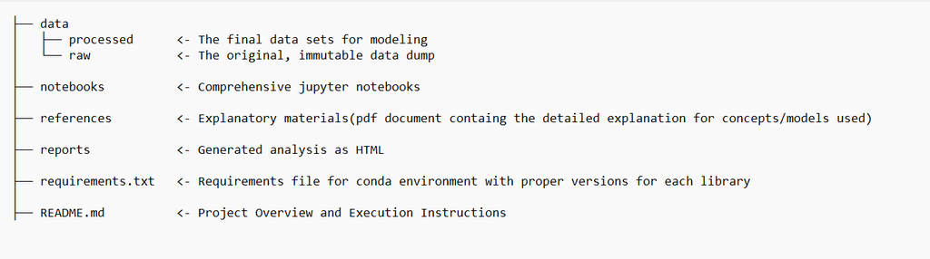

## **Important Libraries**

- **pandas**: pandas is a fast, powerful, flexible, and easy-to-use open-source data analysis and manipulation tool built on top of the Python programming language. Refer to [documentation](https://pandas.pydata.org/) for more information.
- **NumPy**: The fundamental package for scientific computing with Python. Fast and versatile, the NumPy vectorization, indexing, and broadcasting concepts are the de-facto standards of array computing today. NumPy offers comprehensive mathematical functions, random number generators, linear algebra routines, Fourier transforms, and more. Refer to [documentation](https://numpy.org/) for more information. pandas and NumPy are together used for most of the data analysis and manipulation in Python.
- **Matplotlib**: Matplotlib is a comprehensive library for creating static, animated, and interactive visualizations in Python. Refer to [documentation](https://matplotlib.org/) for more information.
- **seaborn**: Seaborn is a Python data visualization library based on matplotlib. It provides a high-level interface for drawing attractive and informative statistical graphics. Refer to [documentation](https://seaborn.pydata.org/) for more information.
- **scikit-learn**: Simple and efficient tools for predictive data analysis

accessible to everybody and reusable in various contexts. It is built on NumPy, SciPy, and matplotlib to support machine learning in Python. Refer to [documentation](https://scikit-learn.org/stable/) for more information.

- **Warnings**:The warnings library provides a way to handle warnings that are generated during program execution. Warnings are typically issued when there is a potential issue with code, but the code still runs without errors. The warnings module provides a way to catch these warnings and handle them in a way that is appropriate for the program. This can be especially useful when developing and debugging code, as warnings can help identify potential issues before they become errors.
- **sys**:The sys library provides access to some system-specific parameters and functions. This library can be used to access system-level information, such as the command line arguments passed to the program, the version of the Python interpreter being used, and more.

## **Package Requirements**

```python
# using warnings module to ignore warnings
import warnings
warnings.filterwarnings('ignore')
```

```python
# Developed and Tested on Python=3.8.10
!pip install numpy==1.24.2 --quiet
!pip install pandas==1.5.3 --quiet
!pip install matplotlib==3.7.0 --quiet
!pip install seaborn==0.12.2 --quiet
!pip install scikit_learn==1.2.2 --quiet
!pip install projectpro --upgrade --quiet
```

```python
# import libraries
import pandas as pd
import numpy as np
import matplotlib.pyplot as plt
import seaborn as sns
import sys
from projectpro import checkpoint,data_pipeline, mo_distance, preserve, save_point, feedback, show_video
checkpoint('fcTel1')
```

```python
# These codes are useful when working with large datasets

# sets the maximum number of columns that will be displayed in a dataframe to 200 for improved data viewing
pd.set_option('display.max_columns', 200)
# sets the maximum number of columns that will be displayed in a dataframe to 300 for improved data viewing
pd.set_option('display.max_rows', 300)
```

```python
# Sets numpy print options to display entire arrays regardless of size
np.set_printoptions(threshold=sys.maxsize)
```

## **Data Reading from Different Sources**

**Click here to view more**

### **Files**

In many cases, the data is stored in the local system. To read the data from the local system, specify the correct path and filename.

### **CSV Format**

Comma-separated values, also known as CSV, is a specific way to store data in a table structure format. The data used in this project is stored in a CSV file. Download the data for the project.

Use following code to read data from csv file using pandas.

```
import pandas as pd
csv_file_path= "D:/ProjectPro/Telecom-Data-Analysis/data/raw_telecom_data.csv.csv"
df = pd.read_csv(csv_file_path)
```

With appropriate csv_file_path, pd.read_csv() function will read the data and store it in df variable.

If you get *FileNotFoundError or No such file or directory*, try checking the path provided in the function. It's possible that python is not able to find the file or directory at a given location.

### **Colab - CSV Format**

```
# mount the google drive
from google.colab import drive
drive.mount('/content/drive')
csv_file_path= '/content/drive/MyDrive/project_pro/Telecom Data Analysis Project to Improve Service Quality/raw_telecom_data.csv.csv'
df = pd.read_csv(csv_file_path)
```

### **AWS S3 - CSV**

Use the S3 public link to read the CSV file directly into a pandas DataFrame

```
s3_link = 'https://s3.amazonaws.com/projex.dezyre.com/telecom-data-analysis-project/materials/raw_telecom_data.csv'
df = pd.read_csv(s3_link)
```

### **Database**

Most organizations store their data in databases such as MS SQL. Microsoft SQL Server (MS SQL) is a relational database management system developed by Microsoft. A BAK file in Microsoft SQL Server is a backup file that contains a copy of a SQL Server database at a specific point in time. It is essentially a binary representation of the database and includes all its data, tables, schema, indexes, stored procedures, and other objects.

#### **Installing MS SQL Management Studio**

To install Microsoft SQL Server Management Studio, you can follow these steps:

- Go to the Microsoft SQL Server Downloads page (https://www.microsoft.com/en-us/sql-server/sql-server-downloads) and click on the "Download now" button for the version of SQL Server Management Studio that you want to install.
- Follow the instructions on the screen to download the installation file to your computer.
- Once the download is complete, locate the installation file and double-click on it to start the installation process.

#### **Restore a BAK file in MS SQL**

- Open SQL Server Management Studio and connect to the SQL Server instance to which you want to upload the BAK file.
- Right-click on the Databases folder in the Object Explorer pane and select "Restore Database..." from the context menu.
- In the "Restore Database" dialog box, select the "Device" option under the "Source" section.
- Click on the "..." button to open the "Select backup devices" dialog box.

In the "Select backup devices" dialog box, click on the "Add" button to add the BAK file that you want to upload.

- In the "Locate Backup File" dialog box, browse to the location where the BAK file is stored in the Telecom Data Analysis Project to Improve Service Quality directory under the ‘data’ folder, select the file, and click on the "OK" button.
- Back in the "Select backup devices" dialog box, the BAK file you added should now be listed under "Backup media:".
- Click on the "OK" button to close the "Select backup devices" dialog box.

In the "Restore Database" dialog box, you should see the BAK file listed in the "Backup sets to restore" section.

- By default, the original database name and file locations from the BAK file will be used. If you want to restore the database with a different name or to a different location, you can modify the "To database" and "Restore as" options under the "General" section.
- Click the "Options" tab for additional restore options.
- If you want to overwrite an existing database with the same name, you can select the "Overwrite the existing database (WITH REPLACE)" option under the "Restore options" section.
- Click on the "OK" button to start the restore process.
- Once the restore process is complete, you should see a message indicating that the restore was successful.

#### **Read Data from DB to Python**

The data can be accessed by secret credentials, which will be in the following format.

```
import pyodbc
import pandas as pd
connection = pyodbc.connect('DRIVER={ODBC Driver 17 for SQL Server};\
                       SERVER=server_name;\
                       PORT=1433;\
                       DATABASE=database_name;\
                       UID=admin;\
                       PWD=password')
```

#### **Steps to install ODBC driver**

- Go to the Microsoft Download Center page for the ODBC Driver 17 for SQL Server: https://www.microsoft.com/en-us/download/details.aspx?id=56567
- Select the download button that corresponds to the operating system you are using.
- Select the language you want to use for the installer, then click the download button.
- Once the download is complete, run the installer.
- Accept the license terms, then select the features you want to install.

Choose a location to install the driver, or use the default location.

- Complete the installation process by following the instructions provided by the installer.
- Once the installation is complete, you can use the ODBC Driver 17 for SQL Server to connect to SQL Server databases from applications that support ODBC connectivity.

#### **Query to read the data into Pandas**

```
query = '''select * from raw_month_1_data
           UNION ALL
            select * from raw_month_2_data
            UNION ALL
            select * from raw_month_3_data
            UNION ALL
            select * from raw_month_4_data
            UNION ALL
            select * from raw_month_5_data
            UNION ALL
            select * from raw_month_6_data
            UNION ALL
            select * from raw_month_7_data
            UNION ALL
            select * from raw_month_8_data
            UNION ALL
            select * from raw_month_9_data
            UNION ALL
            select * from raw_month_10_data
            UNION ALL
            select * from raw_month_11_data
            UNION ALL
            select * from raw_month_12_data
            UNION ALL
            select * from raw_month_13_data
            UNION ALL
            select * from raw_month_14_data'''
raw_data = pd.read_sql(query,connection)
```

## **Data Exploration**

Data exploration is a critical step in the data analysis process, where you examine the dataset to gain a preliminary understanding of the data, detect patterns, and identify potential issues that may need further investigation. Data exploration is important because it helps to provide a solid foundation for subsequent data analysis tasks, hypothesis testing and data visualization.

Data exploration is also important because it can help you to identify an appropriate approach for analyzing the data.

Here are the various functions that help us explore and understand the data.

- Shape: Shape is used to identify the dimensions of the dataset. It gives the number of rows and columns present in the dataset. Knowing the dimensions of the dataset is important to understand the amount of data available for analysis and to determine the feasibility of different methods of analysis.
- Head: The head function is used to display the top five rows of the dataset. It helps us to understand the structure and organization of the dataset. This function gives an idea of what data is present in the dataset, what the column headers are, and how the data is organized.
- Tail: The tail function is used to display the bottom five rows of the dataset. It provides the same information as the head function but for the bottom rows. The tail function is particularly useful when dealing with large datasets, as it can be time-consuming to scroll through all the rows.
- Describe: The describe function provides a summary of the numerical columns in the dataset. It includes the count, mean, standard deviation, minimum, and maximum values, as well as the quartiles. It helps to understand the distribution of the data, the presence of any outliers, and potential issues that can affect the model's accuracy.
- Isnull: The isnull function is used to identify missing values in the dataset. It returns a Boolean value for each cell, indicating whether it is null or not. This function is useful to identify the presence of missing data, which can be problematic for regression analysis.
- Dropna: The dropna function is used to remove rows or columns with missing data. It is used to remove any observations or variables with missing data, which can lead to biased results in the regression analysis. The dropna function is used after identifying the missing data with the isnull function.
- Columns: The .columns method is a built-in function that is used to display the column names of a pandas DataFrame or Series. It returns an array-like object that contains the names of the columns in the order in which they appear in the original DataFrame or Series. It can be used to obtain a quick overview of the variables in a dataset and their names.

```python
# data reading with csv
df = pd.read_csv('https://s3.amazonaws.com/projex.dezyre.com/telecom-data-analysis-project/materials/raw_telecom_data.csv')
```

```python
# exploring the top 5 rows
df.head(n=5)
```

|  | Customer ID | Month of Joining | Month | zip_code | Gender | Age | Married | Dependents | Number of Dependents | Location ID | Service ID | state | county | timezone | area_codes | country | latitude | longitude | arpu | roam_ic | roam_og | loc_og_t2t | loc_og_t2m | loc_og_t2f | loc_og_t2c | std_og_t2t | std_og_t2m | std_og_t2f | std_og_t2c | … |
| --- | --- | --- | --- | --- | --- | --- | --- | --- | --- | --- | --- | --- | --- | --- | --- | --- | --- | --- | --- | --- | --- | --- | --- | --- | --- | --- | --- | --- | --- | --- |
| 0 | hthjctifkiudi0 | 1 | 1 | 71638 | Female | 36 | No | No | 0 | jeavwsrtakgq0 | bfbrnsqreveeuafgps0 | AR | Chicot County | America/Chicago | 870.0 | US | 33.52 | -91.43 | 273.07 | 18.88 | 78.59 | 280.32 | 30.97 | 5.71 | 1.79 | 25.71 | 175.56 | 0.47 | 0.0 | … |
| 1 | uqdtniwvxqzeu1 | 6 | 6 | 72566 | Male | 1 | No | No | 0 | qcvetdmalnkw1 | tkqnsqflrdatnqapsh1 | AR | Izard County | America/Chicago | 870.0 | US | 36.22 | -92.08 | -329.96 | 69.46 | 72.08 | 255.73 | 148.80 | 30.00 | 7.61 | 308.29 | 265.20 | 10.82 | 0.0 | … |
| 2 | uqdtniwvxqzeu1 | 6 | 7 | 72566 | Male | 1 | No | No | 0 | qcvetdmalnkw1 | tkqnsqflrdatnqapsh1 | AR | Izard County | America/Chicago | 870.0 | US | 36.22 | -92.08 | 101.22 | 1012.60 | 115.26 | 52.95 | NaN | 103.28 | 15.71 | 244.20 | 15.19 | NaN | NaN | … |
| 3 | uqdtniwvxqzeu1 | 6 | 8 | 72566 | Male | 1 | No | No | 0 | qcvetdmalnkw1 | tkqnsqflrdatnqapsh1 | AR | Izard County | America/Chicago | 870.0 | US | 36.22 | -92.08 | 215.48 | 84.18 | 99.85 | 140.51 | 4006.99 | 280.86 | 6.33 | 346.14 | 103.15 | 183.53 | 0.0 | … |
| 4 | uqdtniwvxqzeu1 | 6 | 9 | 72566 | Male | 1 | No | No | 0 | qcvetdmalnkw1 | tkqnsqflrdatnqapsh1 | AR | Izard County | America/Chicago | 870.0 | US | 36.22 | -92.08 | 636.55 | 0.00 | 0.00 | 0.00 | 0.00 | 45.00 | 0.00 | 0.00 | 0.00 | 45.00 | 0.0 | … |

```python
# shape of the dataset
df.shape
```

```
(653753, 74)
```

**Observation**: The dataset has 653,753 rows and 74 columns. The number of rows represents the number of records or observations in the dataset, while the number of columns represents the number of features or variables associated with each observation.

```python
# finding the columns of the dataset
df.columns
```

```
Index(['Customer ID', 'Month of Joining', 'Month', 'zip_code', 'Gender', 'Age',
       'Married', 'Dependents', 'Number of Dependents', 'Location ID',
       'Service ID', 'state', 'county', 'timezone', 'area_codes', 'country',
       'latitude', 'longitude', 'arpu', 'roam_ic', 'roam_og', 'loc_og_t2t',
       'loc_og_t2m', 'loc_og_t2f', 'loc_og_t2c', 'std_og_t2t', 'std_og_t2m',
       'std_og_t2f', 'std_og_t2c', 'isd_og', 'spl_og', 'og_others',
       'loc_ic_t2t', 'loc_ic_t2m', 'loc_ic_t2f', 'std_ic_t2t', 'std_ic_t2m',
       'std_ic_t2f', 'std_ic_t2o', 'spl_ic', 'isd_ic', 'ic_others',
       'total_rech_amt', 'total_rech_data', 'vol_4g', 'vol_5g', 'arpu_5g',
       'arpu_4g', 'night_pck_user', 'fb_user', 'aug_vbc_5g', 'Churn Value',
       'Referred a Friend', 'Number of Referrals', 'Phone Service',
       'Multiple Lines', 'Internet Service', 'Internet Type',
       'Streaming Data Consumption', 'Online Security', 'Online Backup',
       'Device Protection Plan', 'Premium Tech Support', 'Streaming TV',
       'Streaming Movies', 'Streaming Music', 'Unlimited Data',
       'Payment Method', 'Status ID', 'Satisfaction Score', 'Churn Category',
       'Churn Reason', 'Customer Status', 'offer'],
      dtype='object')
```

## **Data Dictionary**

Exploratory Data Analysis (EDA) is a crucial step in any data-driven project, especially when working with datasets that are unfamiliar. In such cases, it is essential to understand the characteristics of the data, identify patterns and trends, and uncover insights that may be hidden in the data. Through EDA, we can discover the problems our customers face and the areas in which we can improve our services.

To conduct EDA, we need to have a clear understanding of the variables in our dataset, and that is where a data dictionary comes in handy.

[output not shown]

## **Hypothesis-Driven Exploratory Data Analysis (EDA)**

A hypothesis is a tentative explanation for a phenomenon or relationship between variables that can be tested using data. In data analysis, a hypothesis is a statement about the relationship between two or more variables that we want to test by analyzing the data.

Hypothesis-driven EDA is an approach to data analysis that involves formulating hypotheses about the relationships between variables in a dataset and using data exploration techniques to test those hypotheses. The purpose of this approach is to identify patterns or trends in the data that accept or reject the initial or null hypotheses.

This approach is important because it helps to guide the data exploration process and can provide more meaningful insights than random exploratory data analysis.

The process of conducting hypothesis-driven EDA typically involves the following steps:

- **Formulating a hypothesis**: Hypothesis generation is an educated “guess” of various factors that are impacting the business problem that needs to be solved using machine learning. This involves identifying a question or problem that needs to be addressed and formulating a specific hypothesis/assumption about the relationship between the variables in the data.
- **Choosing appropriate visualization techniques**: Once the hypothesis has been formulated, we need to choose the appropriate visualization techniques to explore the data and test the hypothesis to see if what we thought is actually similar to what data is trying to say.
- **Data exploration and analysis**: We then conduct in-depth analysis, to examine the data to identify any patterns or relationships that support or reject the hypothesis.
- **Evaluate and refine hypotheses**: Evaluate the results of your analysis and refine or generate new hypotheses based on the findings.
- **Communicate results**: Communicate the results of your analysis and the insights gained from testing the hypotheses to stakeholders.

Here are some key assumptions and hypotheses that we can make based on the initial analysis of the dataset:

- The demographic data represents the customer's location and we assume that no customers have changed location.
- A customer can come back to the telecom service provided once they have churned.
- The customer ID is a unique identifier that represents the customer's journey across months. However, we do not have granular data, nor do we know which quarter the data is for.
- The location ID and service ID seem to go hand in hand.
- Customers with higher ARPU should not churn as it would negatively impact the company's revenue.
- The offers provided to the customers are given to either prevent churn, increase satisfaction or engagement, but we don't have any information about the specific offers provided to each customer.
- We assume that the satisfaction score and offer were measured in the same month.
- We don't have any information about the basis for the offers given to the customers.
- We don't know which customers have been good or bad to the organization.
- We know the customers have churned but we don't have any information about when a customer is about to churn, which is a separate investigation.

From here onwards we will explore the data and decide the problems we want to solve

Let us start with customer ID as that is the primary column

## **Univariate Data Analysis**

Univariate data analysis is a statistical method that involves the examination of one variable at a time. It is a method of analysis that focuses on understanding the distribution and properties of a single variable in a dataset.

In univariate analysis, statistical techniques are used to describe and summarize the characteristics of the variable under investigation. Measures such as mean, median, mode, range, standard deviation, and variance are used to describe the central tendency and spread of the data. Graphical representations, such as histograms, frequency plots, and box plots, are used to visualize the distribution of the data.

Univariate analysis is often used as a preliminary step in data analysis to identify patterns, trends, and outliers in the data. It is also used to explore relationships between variables and to test hypotheses about the characteristics of the data.

### **Univariate Plots**

- A histogram is a bar graph that represents the frequency distribution of a set of data. It shows how many data points fall into each range of values or bin. The bars in the histogram represent the frequency of data points within a given range, and the height of each bar represents the number of data points in that bin.
- A density plot is a smoothed representation of the distribution of the data, which is calculated by fitting a probability density function to the histogram of the data. It shows the shape of the distribution and provides a visual representation of the relative density of the data at different values.
- A box plot, also known as a box-and-whisker plot, is a graphical representation of the distribution of a set of data. It shows the median, quartiles, and outliers of the data in a compact and easily interpretable format. The box in the plot represents the interquartile range (IQR), which is the range between the first and third quartile. The whiskers extend from the box to the minimum and maximum values of the data, and any outliers are plotted as individual points outside the whiskers.
- A violin plot is a combination of a density plot and a box plot, showing the density of the data along the y-axis and the distribution along the x-axis. It shows the distribution of the data in a compact format, and provides information on the central tendency, spread, and skewness of the data.
- Distribution plots are an important tool for exploratory data analysis and can help in understanding the distribution of the data, identifying patterns and outliers, and making informed decisions about the data. They provide a visual representation of the data and can be used to identify potential issues with the data, such as non-normality or outliers.
- Bar plots: Bar plots are plots that display the frequency, proportion, or percentage of categorical data using bars, where the length of the bar represents the value of the data being displayed.
- Pie charts: Pie charts are plots that display the proportion or percentage of categorical data using a circular chart, where each slice of the chart represents a category and the size of the slice represents the proportion or percentage of the data.
- Count plots: Count plots are similar to bar plots, but they display the frequency of categorical data rather than the proportion or percentage.
- Line plots: Line plots are plots that display the relationship between two variables by connecting data points with a line.

### **Customer ID**

We have no idea how many customers we have over how many months. Let's see that.

```python
# To get the number of unique customers in the dataset
len(df["Customer ID"].unique())
```

```
98230
```

```python
# To get the number of unique months in the dataset
len(df["Month"].unique())
```

```
14
```

There are 98,230 unique customers in the dataset, and the data spans across 14 months. With this knowledge, we can now move forward with a more comprehensive analysis.

```python
# To get the basic information of the dataset
df.info()
```

```
<class 'pandas.core.frame.DataFrame'>
RangeIndex: 653753 entries, 0 to 653752
Data columns (total 74 columns):
 #   Column                      Non-Null Count   Dtype
---  ------                      --------------   -----
 0   Customer ID                 653753 non-null  object
 1   Month of Joining            653753 non-null  int64
 2   Month                       653753 non-null  int64
 3   zip_code                    653753 non-null  int64
 4   Gender                      643729 non-null  object
 5   Age                         653753 non-null  int64
 6   Married                     639377 non-null  object
 7   Dependents                  629129 non-null  object
 8   Number of Dependents        653753 non-null  int64
 9   Location ID                 653753 non-null  object
```

[output cut: 66 more lines]

**Observation:** There are no null values in the Customer ID, Month of Joining, or Month columns.

Let us plot how many customers are joining in each month

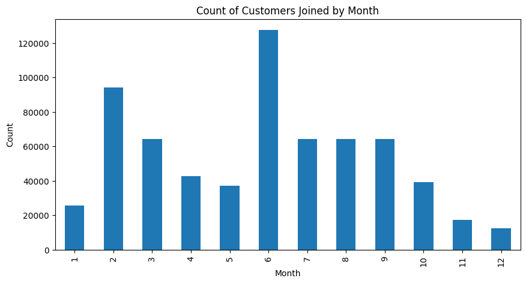

```python
# To generate a bar plot of the count of customers who joined the telecom service in each month, sorted by month
df['Month of Joining'].astype(int).value_counts().sort_index().plot.bar(figsize=(10,5))
plt.title('Count of Customers Joined by Month')
plt.xlabel('Month')
plt.ylabel('Count')
plt.show()
```

**Observation**: A large number of customers joined in June.It could be due to a seasonal promotion or marketing campaign that was particularly effective, or it could be due to external factors such as changes in the market or industry. Further analysis and context would be needed to make a more informed hypothesis.

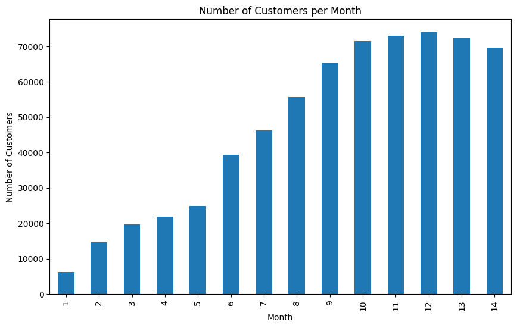

```python
# Distribution of customers across months
customers_per_month = df.groupby("Month")["Customer ID"].nunique()

# Plotting the distribution of customers across months
customers_per_month.plot(kind="bar", figsize=(10, 6))
plt.title("Number of Customers per Month")
plt.xlabel("Month")
plt.ylabel("Number of Customers")
plt.show()
```

**Observation**: From the graph, we can see that the number of customers steadily increases from January to May, after which there is a sharp increase in June, followed by a steady increase and decreasing trend. This could indicate some issue or change in the company's services or marketing strategy during that period.

Let's look at customer journeys!

```python
# Filtering for customer ID - uqdtniwvxqzeu1
df[df["Customer ID"]=='uqdtniwvxqzeu1']
```

|  | Customer ID | Month of Joining | Month | zip_code | Gender | Age | Married | Dependents | Number of Dependents | Location ID | Service ID | state | county | timezone | area_codes | country | latitude | longitude | arpu | roam_ic | roam_og | loc_og_t2t | loc_og_t2m | loc_og_t2f | loc_og_t2c | std_og_t2t | std_og_t2m | std_og_t2f | std_og_t2c | … |
| --- | --- | --- | --- | --- | --- | --- | --- | --- | --- | --- | --- | --- | --- | --- | --- | --- | --- | --- | --- | --- | --- | --- | --- | --- | --- | --- | --- | --- | --- | --- |
| 1 | uqdtniwvxqzeu1 | 6 | 6 | 72566 | Male | 1 | No | No | 0 | qcvetdmalnkw1 | tkqnsqflrdatnqapsh1 | AR | Izard County | America/Chicago | 870.0 | US | 36.22 | -92.08 | -329.96 | 69.46 | 72.08 | 255.73 | 148.80 | 30.00 | 7.61 | 308.29 | 265.20 | 10.82 | 0.0 | … |
| 2 | uqdtniwvxqzeu1 | 6 | 7 | 72566 | Male | 1 | No | No | 0 | qcvetdmalnkw1 | tkqnsqflrdatnqapsh1 | AR | Izard County | America/Chicago | 870.0 | US | 36.22 | -92.08 | 101.22 | 1012.60 | 115.26 | 52.95 | NaN | 103.28 | 15.71 | 244.20 | 15.19 | NaN | NaN | … |
| 3 | uqdtniwvxqzeu1 | 6 | 8 | 72566 | Male | 1 | No | No | 0 | qcvetdmalnkw1 | tkqnsqflrdatnqapsh1 | AR | Izard County | America/Chicago | 870.0 | US | 36.22 | -92.08 | 215.48 | 84.18 | 99.85 | 140.51 | 4006.99 | 280.86 | 6.33 | 346.14 | 103.15 | 183.53 | 0.0 | … |
| 4 | uqdtniwvxqzeu1 | 6 | 9 | 72566 | Male | 1 | No | No | 0 | qcvetdmalnkw1 | tkqnsqflrdatnqapsh1 | AR | Izard County | America/Chicago | 870.0 | US | 36.22 | -92.08 | 636.55 | 0.00 | 0.00 | 0.00 | 0.00 | 45.00 | 0.00 | 0.00 | 0.00 | 45.00 | 0.0 | … |
| 5 | uqdtniwvxqzeu1 | 6 | 10 | 72566 | Male | 1 | No | No | 0 | qcvetdmalnkw1 | tkqnsqflrdatnqapsh1 | AR | Izard County | America/Chicago | 870.0 | US | 36.22 | -92.08 | 771.79 | 775.76 | 81.54 | 67.47 | 78.41 | 6.75 | 6.97 | 193.49 | 215.74 | 0.18 | 0.0 | … |
| 6 | uqdtniwvxqzeu1 | 6 | 11 | 72566 | Male | 1 | No | No | 0 | qcvetdmalnkw1 | tkqnsqflrdatnqapsh1 | AR | Izard County | America/Chicago | 870.0 | US | 36.22 | -92.08 | 565.53 | 61.23 | 75.63 | 281.94 | 1691.32 | 48.84 | 6.50 | 304.78 | 186.81 | 171.10 | 0.0 | … |
| 7 | uqdtniwvxqzeu1 | 6 | 12 | 72566 | Male | 1 | No | No | 0 | qcvetdmalnkw1 | tkqnsqflrdatnqapsh1 | AR | Izard County | America/Chicago | 870.0 | US | 36.22 | -92.08 | 403.33 | 73.91 | 90.44 | 98.25 | 209.47 | 4.10 | 13.52 | 456.56 | 146.11 | 2.47 | 0.0 | … |
| 8 | uqdtniwvxqzeu1 | 6 | 13 | 72566 | Male | 1 | No | No | 0 | qcvetdmalnkw1 | tkqnsqflrdatnqapsh1 | AR | Izard County | America/Chicago | 870.0 | US | 36.22 | -92.08 | 540.14 | 56.20 | 29.64 | 187.39 | 167.55 | 13.48 | 14.41 | 283.25 | 24.86 | 3.88 | 0.0 | … |
| 9 | uqdtniwvxqzeu1 | 6 | 14 | 72566 | Male | 1 | No | No | 0 | qcvetdmalnkw1 | tkqnsqflrdatnqapsh1 | AR | Izard County | America/Chicago | 870.0 | US | 36.22 | -92.08 | 1330.04 | 1582.05 | 157.20 | 161.81 | 1827.38 | 39.79 | 1.00 | 1362.59 | 5267.31 | 171.81 | 0.0 | … |

**Observation**: We can observe that this consumer joined the company in the sixth month and stayed until the fourteenth month.

```python
# Filtering for customer ID - aabakestdecft46766
df[df["Customer ID"]=='aabakestdecft46766']
```

|  | Customer ID | Month of Joining | Month | zip_code | Gender | Age | Married | Dependents | Number of Dependents | Location ID | Service ID | state | county | timezone | area_codes | country | latitude | longitude | arpu | roam_ic | roam_og | loc_og_t2t | loc_og_t2m | loc_og_t2f | loc_og_t2c | std_og_t2t | std_og_t2m | std_og_t2f | std_og_t2c | … |
| --- | --- | --- | --- | --- | --- | --- | --- | --- | --- | --- | --- | --- | --- | --- | --- | --- | --- | --- | --- | --- | --- | --- | --- | --- | --- | --- | --- | --- | --- | --- |
| 186597 | aabakestdecft46766 | 3 | 3 | 93290 | Not Specified | 31 | Yes | Not Specified | 0 | wwgmolpjnnym46766 | qijdupdvrwhnvxnddn46766 | CA | Tulare County | America/Los_Angeles | 559.0 | US | 36.33 | -119.29 | 6103.72 | 828.16 | 25.9 | 272.01 | 2563.6 | 0.98 | NaN | NaN | 4543.7 | 148.09 | 0.0 | … |

**Observation**: This consumer joined in the third month and left in the same month.

```python
# Compute basic statistics of count of rows per customer
df.groupby(['Customer ID']).size().describe()
```

```
count    98230.000000
mean         6.655329
std          3.377418
min          1.000000
25%          4.000000
50%          6.000000
75%          9.000000
max         14.000000
dtype: float64
```

**Observation**: The average duration of a customer is 6 months, then we can generate the following hypotheses:

- The company needs to improve their customer retention strategies to increase the average duration of customers.
- The company needs to evaluate their pricing strategies to retain customers for a longer duration.
- The company need to focus on improving the quality of their services to increase customer loyalty and prolong their duration of service.

To understand the actual problem we need to analyze other variables and see what insights they show in order to support or reject these hypotheses.

```python
# Count the number of customers with a particular number of rows
df.groupby(['Customer ID']).size().value_counts()
```

```
9     13086
6     11896
5      9761
7      9647
8      8368
3      8061
1      7284
4      7176
13     5603
2      5069
12     4441
10     3631
11     3441
14      766
dtype: int64
```

**Observation**: This shows that more people are present in 5 to 9 month bracket. We can generate the following hypotheses:

- Customers who stay with the telecom service provider for a longer duration are more likely to stay for 5-9 months.
- Customers may be facing some issues or problems with the service after 9 months, leading to a higher churn rate after that period.

### **Zip Code**

Some possible hypotheses that could be formed are:

- The distribution of customers across zip codes follows a normal distribution.
- There are a few zip codes with significantly more customers than others.
- The distribution of customers across zip codes is skewed to the right, with the majority of zip codes having fewer customers.

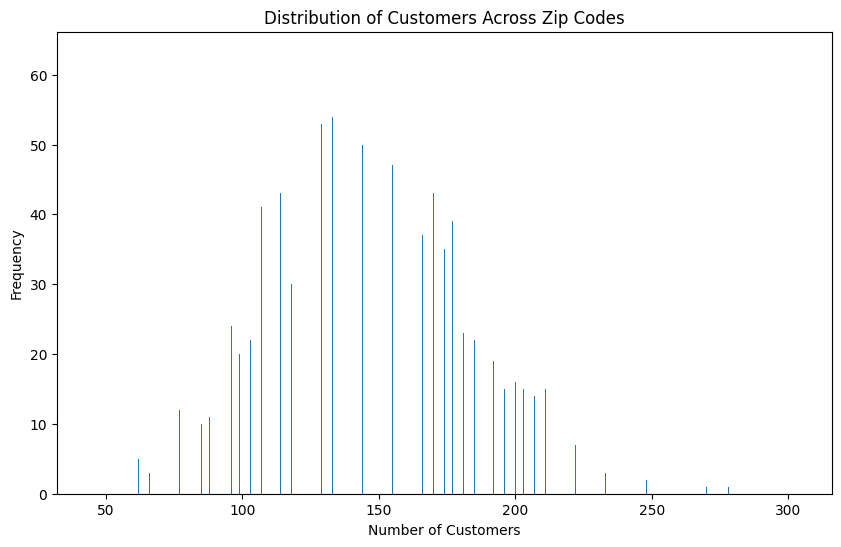

```python
# Number of unique zip codes in the dataset
num_unique_zips = df['zip_code'].nunique()

# Number of customers in each zip code
cust_per_zip = df['zip_code'].value_counts()

# Summary statistics of the number of customers per zip code
data_pipeline("fcTel1")
cust_per_zip.describe()

# Plotting the distribution of customers across zip codes
cust_per_zip.plot(kind='hist', bins=num_unique_zips, figsize=(10,6))
plt.title('Distribution of Customers Across Zip Codes')
plt.xlabel('Number of Customers')
plt.ylabel('Frequency')
plt.show()
```

**Observation**: As we can see the distribution confirms our hypothesis of normal distribution.

As the distribution of customers across zip codes does not show much skewness, it suggests that the customer base is relatively evenly distributed across zip codes. There are no clear pockets of customers in particular zip codes that stand out as being much more popular than others. This could be a positive sign for the business, as it suggests that the customer base is broad and not overly reliant on a particular geographic area.

### **Gender**

```python
# Count the number of customers in each gender category
gender_counts = df['Gender'].value_counts()

# Print the gender counts
print(gender_counts)
```

```
Female           278668
Male             276917
Not Specified     48938
Other             39206
Name: Gender, dtype: int64
```

```python
# Counting the number of unique customers whose gender is missing
print('Customers whose gender is missing:' ,df[df['Gender'].isna()]['Customer ID'].nunique())
```

```
Customers whose gender is missing: 1487
```

**Observation**: We can observe that 1487 consumers have no gender. Let's impute it with "Not specified".

```python
# Filling missing values in the Gender column with 'Not Specified'
df['Gender'] = df['Gender'].fillna('Not Specified')

# Counting the number of customers for each gender, including those with missing values
df['Gender'].value_counts(dropna=False)
```

```
Female           278668
Male             276917
Not Specified     58962
Other             39206
Name: Gender, dtype: int64
```

### **Age**

Possible hypotheses that could formed for "Age" column are:

- Most customers fall in the age group of 20 to 40 years.
- There will be outliers present in the age column as some customers might have entered invalid age.

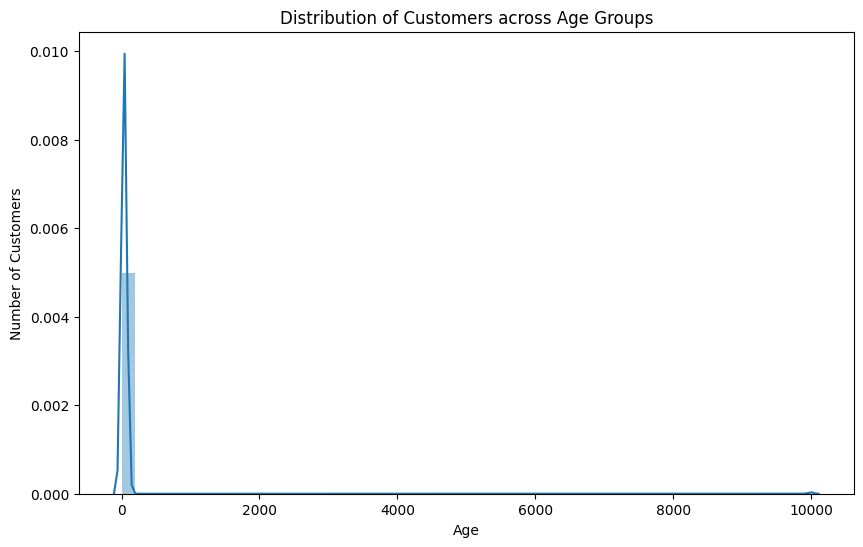

```
count    653753.000000
mean         65.357427
std         538.575025
min           1.000000
25%          27.000000
50%          33.000000
75%          43.000000
max        9999.000000
Name: Age, dtype: float64
```

```python
# Distribution of customers across age groups
plt.figure(figsize=(10,6))
sns.distplot(df['Age'])
plt.title('Distribution of Customers across Age Groups')
plt.xlabel('Age')
plt.ylabel('Number of Customers')
plt.show()

# Descriptive statistics of age column
df['Age'].describe()
```

**Observation**: As we can see the maximum age is 9999. This proves our hypothesis that there will be outliers present in the age column as some customers might have entered invalid age.

```python
# let's see the sorted age values
df['Age'].sort_values()
```

```
222187       1
413353       1
413352       1
413351       1
413350       1
          ...
34536     9999
34535     9999
110719    9999
380795    9999
142984    9999
Name: Age, Length: 653753, dtype: int64
```

```python
# So we need to replace 9999 by mean or median! or 95th percintle!
df['Age'].quantile([0.8,0.9,0.95,0.99])
```

```
0.80    47.0
0.90    55.0
0.95    62.0
0.99    75.0
Name: Age, dtype: float64
```

```python
# So we need to replace 9999 by mean or median! or 95th percintle!
df['Age'].quantile([0.99,0.999,0.99991,0.999999])
```

```
0.990000      75.0
0.999000    9999.0
0.999910    9999.0
0.999999    9999.0
Name: Age, dtype: float64
```

```python
# Hence we will replace every value in age column by greater than 76 by lets say similar values through imputer.
df['Age'].value_counts()
```

```
25      27994
30      27815
29      27361
27      27233
26      27023
28      26872
33      26315
31      26259
34      25718
32      25396
35      24516
39      16825
40      16761
38      16703
41      16313
```

[output cut: 50 more lines]

```python
# We will fill the NaN's later by using impute method
# For all greater than 75 we will make the age as NaN
df['Age'].replace(9999, np.NaN, inplace=True)
```

```python
# Now replacing Age=1
df['Age'].replace(1, np.NaN, inplace=True)
```

```python
# Extreme Quantiles
df['Age'].quantile([0.99,0.999,0.99991,0.999999])
```

```
0.990000    74.0
0.999000    79.0
0.999910    80.0
0.999999    80.0
Name: Age, dtype: float64
```

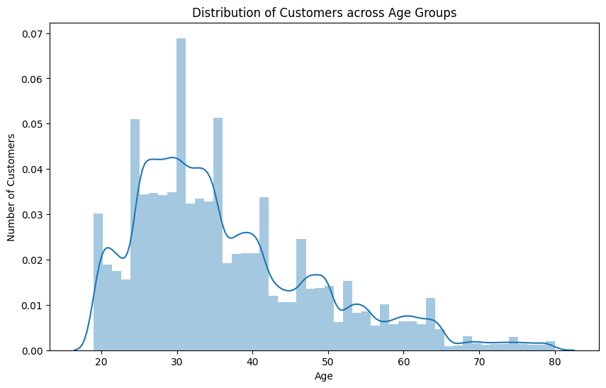

```python
# Distribution of customers across age groups
plt.figure(figsize=(10,6))
sns.distplot(df['Age'])
plt.title('Distribution of Customers across Age Groups')
plt.xlabel('Age')
plt.ylabel('Number of Customers')
plt.show()
```

We will enter null values for Age later.

**Observation**: The data now seems to be valid as it also proves our hypothesis of most of the customer ages would be between 20-40.

### **Married**

```python
# Count of each unique value in the 'Married' column including NaN values
df['Married'].value_counts(dropna=False)
```

```
Yes              279124
No               276240
Not Specified     84013
NaN               14376
Name: Married, dtype: int64
```

```python
# Count of unique customer IDs where 'Married' column is NaN
df[df['Married'].isna()]['Customer ID'].nunique()
```

```
2179
```

```python
# Replacing NaN values in the 'Married' column with 'Not Specified'
df['Married'] = df['Married'].fillna('Not Specified')
```

```python
# Count of each unique value in the 'Married' column after filling NaN values with 'Not Specified'
df['Married'].value_counts(dropna=False)
```

```
Yes              279124
No               276240
Not Specified     98389
Name: Married, dtype: int64
```

### **Dependents**

```python
# Count the number of unique values in "Dependents" column
df['Dependents'].value_counts(dropna=False)
```

```
No               320931
Yes              169579
Not Specified    138619
NaN               24624
Name: Dependents, dtype: int64
```

**Observation**:The Dependents and Number of Dependents columns are linked.

But, for the time being, we will simply replace null with not specified and deal with both columns together in the following section.

```python
# Fill missing values in dependents with "Not Specified"
df['Dependents']=df['Dependents'].fillna('Not Specified')
```

```python
# Count the number of unique values in "Dependents" column after imputation
df['Dependents'].value_counts(dropna=False)
```

```
No               320931
Yes              169579
Not Specified    163243
Name: Dependents, dtype: int64
```

```python
# Percentage of customers with dependents
percent_with_dependents = (df["Dependents"].value_counts(normalize=True) * 100).loc["Yes"]
preserve("fcTel1")
print(f"Percentage of customers with dependents: {percent_with_dependents:.2f}%")
```

```
Percentage of customers with dependents: 25.94%
```

**Observation**: The percentage of customers with dependents gives us insights into the family structure of the customer base. This can help us understand the type of services that are in demand among families and whether there are opportunities to introduce family-oriented plans and promotions.

### **Number of Dependents**

```python
# Counting the number of unique values in Number of Dependents column
df['Number of Dependents'].value_counts(dropna=False)
```

```
0      435554
1       79167
4       39647
2       21156
3       16031
7       15468
6       15137
8       13625
9       13023
699      4945
Name: Number of Dependents, dtype: int64
```

**Observation**: There are no null values in the number of dependents column.

Nonetheless, 699 dependents stand out as an exception in this case. Let's substitute nan and impute them later.

**Problem**:

- Improve customer satisfaction: Customers with dependents have zero dependents constitute the majority of our customer base and could be used to improve customer satisfaction by offering more accurate and relevant products and services to customers based on their needs as customers with dependents more likely have a high ARPU and means they are more invested and have a lesser risk to churn out. Although, they should be tackled with a whole different strategy to ensure their loyalty.

```python
# Replace 699 with Nan
df.loc[df['Number of Dependents']==699,'Number of Dependents']=np.nan
```

```python
# Count the frequency of unique values in the 'Dependents' and 'Number of Dependents' columns
df[['Dependents','Number of Dependents']].value_counts(dropna=False)
```

```
Dependents     Number of Dependents
No             0.0                     254060
Not Specified  0.0                     108943
Yes            0.0                      72551
No             1.0                      45190
Not Specified  1.0                      19096
No             4.0                      18002
Yes            2.0                      15926
               1.0                      14881
               3.0                      11908
               4.0                      11696
               7.0                      11532
               6.0                      11186
               8.0                      10295
Not Specified  4.0                       9949
Yes            9.0                       9604
Not Specified  2.0                       5230
               3.0                       4123
               6.0                       3951
               7.0                       3936
No             NaN                       3679
Not Specified  9.0                       3419
               8.0                       3330
               NaN                       1266
dtype: int64
```

**Observation**:

However, we will not address this in the current notebook.

### **Location ID and Service ID**

```python
# Count the number of unique Location IDs
df['Location ID'].nunique()
```

```
98230
```

```python
# Count the number of unique Service IDs
df['Service ID'].nunique()
```

```
98230
```

**Observation**: It appears that each customer ID has a distinct Location ID and Service ID and they go hand in hand.

```python
# Using value_counts() method to get the count of unique values for Location ID and Service ID columns
df[['Location ID','Service ID']].value_counts(dropna=False)
```

```
Location ID         Service ID
hlrjtcmwztmd130753  enaqvnivkxydixfyqm130753    14
jscprjytujws25932   bfryykgvokxkyfznot25932     14
llgnltpyyoun38767   jsggccqjebwceilwmz38767     14
legwdrxdiaro61600   ntahpedsuygrdtopia61600     14
uvucxidcaizg61475   amgakuqbjlubbntjls61475     14
                                                ..
wsuvsaqtrotn58881   yzcskeospoebdbpzxu58881      1
wswcpmvctflk25234   lpulhrynhoujhifter25234      1
jikgwoxcifwl86729   stdluukccrzawlvstx86729      1
jijxolpufjvz18051   vtcqteigmpqmukrium18051      1
zzzzvucoqifl133665  kcvdllqcwoedvhxtdr133665     1
Length: 98230, dtype: int64
```

**Observation**: The counts of unique values for Location ID and Service ID columns are almost same which indicates that location ID and service ID are related to each other and thus our assumption is proved.

### **State**

```python
# Count the unique values of State column
df['state'].value_counts(dropna=False)
```

```
CA    383500
WA    105313
AR    103551
NM     61389
Name: state, dtype: int64
```

**Observation**: There are no null values in the state column.

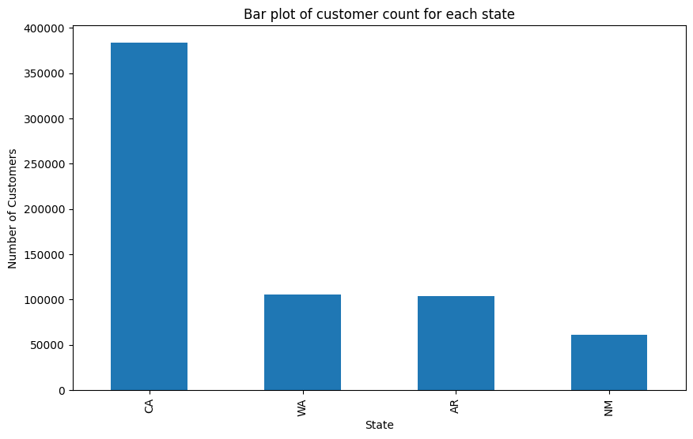

```python
# Bar plot of customer count for each state
plt.figure(figsize=(10,6))
df['state'].value_counts(dropna=False).plot.bar()
plt.title('Bar plot of customer count for each state')
plt.xlabel('State')
plt.ylabel('Number of Customers')
plt.show()
```

```python
# Grouping by state and calculating unique customer count
df.groupby(['state'],as_index=False).agg(Number_of_customers=('Customer ID','nunique'))
```

|  | state | Number_of_customers |
| --- | --- | --- |
| 0 | AR | 15521 |
| 1 | CA | 57665 |
| 2 | NM | 9209 |
| 3 | WA | 15835 |

**Observation**: It can be observed that the maximum number of customers are from California with 57665 Customers IDs.

We earlier saw that the normal distribution of zip codes suggests that customers are evenly distributed across zip codes.

**Hypothesis**:

- It is possible that the state of California has a large number of zip codes among other states.

```python
# Count the number of unique zip codes per state
df.groupby('state')['zip_code'].nunique()
```

```
state
AR     712
CA    2655
NM     428
WA     733
Name: zip_code, dtype: int64
```

Yes! California has maximum zip codes.

**Hypotheses and Problems**

Hypotheses that can be deduced:

- The telecom service provider has a strong presence in California, leading to a higher customer base.
- Customers from California have higher mobile phone usage compared to other states, leading to more subscriptions with the telecom service provider.

These conclusions also lead to the following problems:

- Location-based marketing strategy: The insight that the majority of customers are from California could be used to develop a location-based marketing strategy that targets customers in this state with customized offers, campaigns, and promotions.
- Improve customer distribution: Analyze and bring in more customers from other states to even out the customer distribution and ensure the company is not overly reliant on a particular area.

### **County**

```python
# Group by county and calculate number of unique customers in each county
df.groupby(['county'],as_index=False).agg(Number_of_customers=('Customer ID','nunique')).sort_values(by=['Number_of_customers'])
```

|  | county | Number_of_customers |
| --- | --- | --- |
| 51 | Garfield County | 17 |
| 99 | Mckinley County | 28 |
| 89 | Los Alamos County | 37 |
| 38 | De Baca County | 58 |
| 91 | Luna County | 61 |
| 19 | Chicot County | 63 |
| 58 | Harding County | 67 |
| 6 | Asotin County | 73 |
| 182 | Wahkiakum County | 77 |
| 2 | Alpine County | 79 |
| 14 | Calhoun County | 80 |
| 37 | Dallas County | 81 |
| 25 | Cleveland County | 82 |
| 160 | Skamania County | 89 |
| 78 | Lafayette County | 93 |
| 62 | Howard County | 94 |
| 0 | Adams County | 95 |
| 151 | Scott County | 96 |
| 43 | Drew County | 96 |
| 61 | Hot Spring County | 96 |
| 60 | Hidalgo County | 99 |
| 137 | San Benito County | 109 |
| 11 | Bradley County | 110 |
| 106 | Monroe County | 112 |
| 57 | Guadalupe County | 114 |
| 116 | Ouachita County | 115 |
| 119 | Perry County | 115 |
| 154 | Sevier County | 116 |
| 102 | Miller County | 119 |
| 39 | Del Norte County | 122 |

[output cut: 163 more lines]

```python
# Count the number of missing values in county column
df['county'].isna().sum()
```

```
918
```

**Observations**:

- Los Angeles has the highest number of customers while Garfield county has the lowest number of customers.
- There are 918 missing values in the county column.

**Hypotheses**:

- Customers in densely populated areas (like Los Angeles) may have different preferences and behaviors compared to customers in less populated areas (like Garfield county).

Analyzing customer preferences and behaviors in different locations can help the company target their marketing and promotional strategies effectively.

```python
# Finding the values of state, latitude and longitude where county is missing
df[df['county'].isna()][['state','latitude','longitude']].value_counts()
```

```
state  latitude  longitude
WA     47.42     -122.25      198
AR     34.75     -92.27       191
NM     35.82     -106.20      179
WA     47.85     -122.22      131
NM     32.99     -106.97      112
CA     37.95     -121.29      107
dtype: int64
```

```python
# Finding the county for specific latitude and longitude values
df[(df.latitude==32.99)&(df.longitude==-106.97)]['county'].value_counts(dropna=False)
```

```
NaN    112
Name: county, dtype: int64
```

```python
# Finding the county for specific latitude and longitude values
df[(df.latitude==34.75)&(df.longitude==-92.27)]['county'].value_counts(dropna=False)
```

```
NaN    191
Name: county, dtype: int64
```

```python
# Finding the county for specific latitude and longitude values
df[(df.latitude==35.82)&(df.longitude==-106.20)]['county'].value_counts(dropna=False)
```

```
NaN    179
Name: county, dtype: int64
```

```python
# Finding the county for specific latitude and longitude values
df[(df.latitude==47.85)&(df.longitude==-122.22)]['county'].value_counts(dropna=False)
```

```
NaN    131
Name: county, dtype: int64
```

```python
# Finding the county for specific latitude and longitude values
df[(df.latitude== 37.95)&(df.longitude==-121.29 )]['state'].value_counts(dropna=False)
```

```
CA    107
Name: state, dtype: int64
```

```python
# Replacing missing values in county with 'Unknown'
df['county']=df['county'].fillna('Unknown')
```

**Observation**: We see that there are some values of latitude and longitude for which the county value is missing (NaN). To fill in these missing values, we can find the county corresponding to those latitude and longitude values. However, for this exercise, we will simply replace the missing county values with 'Unknown'.

### **Timezone**

```python
# Count the number of customers in each timezone
df['timezone'].value_counts(dropna=False)
```

```
America/Los_Angeles    488813
America/Chicago        103404
America/Denver          61389
NaN                       147
Name: timezone, dtype: int64
```

```python
# Identify the customers with missing timezone and their state and county information
df[df['timezone'].isna()][['state','county']].value_counts(dropna=False)
```

```
state  county
AR     Craighead County    147
dtype: int64
```

```python
# Check the unique timezone value for customers in Craighead County
df[df.county=='Craighead County'].timezone.unique()
```

```
array([nan, 'America/Chicago'], dtype=object)
```

```python
# Fill the missing timezone values with "America/Chicago"
df['timezone']=df['timezone'].fillna('America/Chicago')
```

**Observation**: There are 147 null values for timezone, all of which belong to Craighead County. The corresponding timezone for this county is "America/Chicago", so we safely replaced the missing values with this timezone.

**Hypothesis**:

- Customers in different timezones may have different calling behavior or usage patterns, which can affect the revenue or service quality of the company.

We'll have to analyze and see later.

### **Area Codes**

```python
# Count the values of area codes
df['area_codes'].value_counts(dropna=False)
```

```
8.700000e+02    58440
5.050000e+02    42415
NaN             39657
5.090000e+02    38585
5.300000e+02    32844
3.600000e+02    31031
5.590000e+02    22731
7.070000e+02    22095
2.090000e+02    21601
9.160000e+02    19833
5.010000e+02    19443
4.790000e+02    18577
5.750000e+02    17872
7.600000e+02    16975
8.050000e+02    16441
6.190000e+02    14822
2.130000e+02    14727
4.150000e+02    11374
6.610000e+02    10954
2.530000e+02    10852
6.260000e+02    10382
5.100000e+02    10001
4.080000e+02     9844
7.140000e+02     9372
9.090000e+02     8873
5.620000e+02     7832
2.060000e+02     7236
9.510000e+02     7165
4.250000e+02     6667
6.500000e+02     6590
8.310000e+02     6385
3.100000e+02     5600
8.180000e+02     5428
9.250000e+02     4984
9.490000e+02     4228
3.230000e+02     4038
6.577140e+05     2973
4.427600e+05     2823
3.104240e+05     2706
9.099510e+05     2320
```

[output cut: 121 more lines]

```
5.018700e+05      116
7.149100e+14      116
4.252063e+08      115
5.596610e+05      114
6.694080e+05      112
3.602530e+05      107
4.795010e+05      101
3.100000e+20      101
9.255107e+08      100
2.533600e+05       95
6.263230e+05       93
7.606610e+05       83
6.197600e+05       79
5.302090e+05       74
Name: area_codes, dtype: int64
```

There are some missing values. Let us explore deeper.

```python
# Count the values of state and county for missing values of area codes
df[df['area_codes'].isna()][['state','county']].value_counts(dropna=False)
```

```
state  county
CA     San Bernardino County     4339
       Los Angeles County        2837
WA     Pierce County             1944
CA     El Dorado County          1921
       Placer County             1709
       Kern County               1572
AR     Independence County       1540
CA     Marin County              1389
WA     King County               1375
CA     Trinity County            1366
       Contra Costa County       1241
       San Diego County          1228
WA     Kitsap County             1102
CA     Riverside County          1087
       Monterey County           1065
       Yolo County                962
WA     Snohomish County           839
CA     San Mateo County           831
       Humboldt County            821
AR     Jackson County             785
CA     San Luis Obispo County     682
       Santa Barbara County       620
AR     Jefferson County           587
       Cleburne County            526
CA     Orange County              489
       Sacramento County          459
WA     Mason County               406
AR     Lonoke County              396
       Polk County                371
CA     Mono County                366
NM     Unknown                    291
CA     Santa Clara County         240
AR     Nevada County              197
       Unknown                    191
       Pulaski County             184
       Phillips County            177
       Madison County             176
WA     Lewis County               172
CA     Inyo County                168
```

[output cut: 9 more lines]

```
       Whitman County             139
CA     Calaveras County           135
WA     Thurston County            134
       Unknown                    131
CA     Amador County              128
AR     Ashley County              124
       Pope County                121
CA     Tulare County              112
       Unknown                    107
AR     Fulton County              104
WA     Grays Harbor County        102
       Skagit County              102
CA     Mariposa County             98
AR     Carroll County              89
dtype: int64
```

Let's see if one county has only one area codes value.

```python
# Count the values of County and area codes
df[['county','area_codes']].value_counts(dropna=False)
```

```
county                 area_codes
Sacramento County      916.0         18145
San Diego County       619.0         14822
Los Angeles County     213.0         14727
Fresno County          559.0         14412
Los Angeles County     626.0         10382
                                     ...
                       760661.0         83
San Diego County       619760.0         79
El Dorado County       530209.0         74
Mono County            530.0            73
San Bernardino County  661760.0         64
Length: 507, dtype: int64
```

We can verify with the company about this.

For the time being, let us simply replace na with unknown.

```python
# Filling the missing value with Unknown
df['area_codes']=df['area_codes'].fillna('Unknown')
```

### **Latitude and Longitude**

```python
# Check the number of nulls in latitude
df['latitude'].isna().sum()
```

```
0
```

```python
# Check the number of nulls in longitude
df['longitude'].isna().sum()
```

```
0
```

```python
# Count the unique values of latitude and longitude
df[['latitude','longitude']].value_counts()
```

```
latitude  longitude
38.58     -121.49      6584
35.11     -106.62      3382
47.61     -122.33      2177
34.72     -92.35       2012
38.55     -121.49      1886
                       ...
47.62     -122.02        52
47.65     -122.55        49
32.87     -114.72        49
35.34     -115.43        46
36.03     -93.92         45
Length: 4108, dtype: int64
```

Are these from California, as there are many maximum consumers from that state?

```python
# Checking if the latitude and longitude values are from CA
df[df['latitude']==38.58][['latitude', 'longitude', 'state']].value_counts()
```

```
latitude  longitude  state
38.58     -121.49    CA       6584
          -121.37    CA        154
          -121.30    CA        100
dtype: int64
```

Yes!

**Observation**:

- There are no null values in latitude and longitude, and the maximum number of rows is 38.58, -121.49.

### **Average Revenue per User (ARPU)**

Some hypotheses for univariate analysis are:

- We don't know which customers have been good or bad to the organization.
- The distribution of arpu values might be skewed. The median arpu might be a better measure of central tendency than the mean arpu.
- There might be some outliers in arpu values.

```python
# Check the null values in ARPU
df['arpu'].isna().sum()
```

```
0
```

There are no null values in arpu.

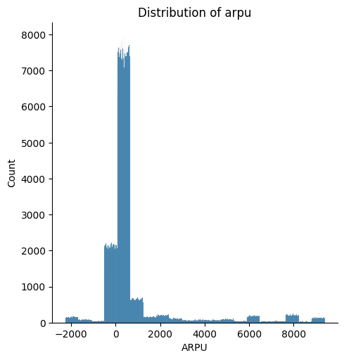

```python
# Distribution plot
preserve("fcTel1")
plt.figure(figsize=(10,6))
sns.displot(df['arpu'])
plt.title('Distribution of arpu')
plt.xlabel('ARPU')
plt.ylabel('Count')
plt.show()
```

**Observation**:

- The distribution of ARPU values is right-skewed, with most values concentrated below 500 which indicates very high ARPU values for a few customers proving our hypotheses.
- There are some negative ARPU values, which may be due to refunds. A negative ARPU means that the company is losing money on a per-user basis, rather than making a profit. It is not uncommon for telecom companies to have negative ARPU due to the high costs associated with acquiring and servicing customers.

```python
# ARPU is negative here.
# Lets investigate
df.arpu.describe()
```

```
count    653753.000000
mean        781.196280
std        1807.269437
min       -2258.680000
25%         118.940000
50%         348.540000
75%         580.650000
max        9394.500000
Name: arpu, dtype: float64
```

```python
# Now let us investigate how many people have negative arpu

df[df['arpu']<0].shape
```

```
(115942, 74)
```

```python
# So nearly 115K customers have negative ARPU.
# Let's calculate the percentage
115942/df.shape[0]
```

```
0.17734832574382067
```

**Observation**:

The fact that 17% of the people have negative arpu means that a significant proportion of the customer base is not generating revenue for the telecom company.

This could be due to a number of reasons, such as inactive accounts, delinquent accounts, or accounts with outstanding balances.

To understand more about this issue, we can investigate other variables that may be related to negative arpu, such as churn status. We can also look at the distribution of negative arpu values across different demographic groups, such as age, gender, and location, to see if there are any patterns or trends.

Additionally, we can explore whether there are any correlations between negative arpu and other variables, such as usage patterns, service subscriptions, and customer satisfaction scores to understand what's causing this behaviour.

Overall, further investigation is needed to fully understand the implications of negative arpu for the telecom company.

### **Average revenue per user over 4G and 5G network (ARPU 4G & ARPU 5G)**

```python
# Check nulls
df['arpu_4g'].isna().sum()
```

```
212319
```

```python
# Check nulls
df['arpu_5g'].isna().sum()
```

```
210855
```

There are about 210K null values in arpu_4g and arpu_5g.

```python
# We have not been given any information if adding these 2 up will make overall arpu
# Let us analyze all 3 variables together

(df['arpu_5g']+df['arpu_4g']==df['arpu']).value_counts(dropna=False)
```

```
False    653749
True          4
dtype: int64
```

**Observation**: arpu_4g and arpu_5g does not add up to give overall arpu.

**Hypothesis**:

`Overall ARPU = arpu_4g + arpu_5g + other_arpu_components`

where `other_arpu_components` represent the revenue generated from other sources such as voice calls, messaging, and data usage on 2G and 3G networks.

Lets see how can we deal with null values in these columns

```python
# Frequency count of different values in the 'total_rech_data' column for users who did not have any data recharge
# and also have missing values in both 'arpu_4g' and 'arpu_5g' columns
df[(df['arpu_4g'].isna())&(df['arpu_5g'].isna())]['total_rech_data'].value_counts(dropna=False)
```

```
NaN    195182
13        802
30        744
26        725
27        711
12        656
16        583
29        458
25        386
31        370
19        332
15        317
32        159
18        152
24         97
20         41
Name: total_rech_data, dtype: int64
```

**Observation**:

- Maximum values with no `arpu_4g` and `arpu_5g` have no recharge for internet service, then it's safe to assume that the null values in arpu_4g and arpu_5g also represent customers who have not recharged for internet service. We will impute this values once we analyze the `total_rech_data` variable.

### **Night Pack User**

```python
# Check the value counts
df['night_pck_user'].value_counts(dropna=False)
```

```
NaN    373103
0.0    219570
1.0     61080
Name: night_pck_user, dtype: int64
```

**Observation**: Since the `night_pck_user` column has more than 50% missing values, it's not wise to impute those missing values as it may lead to biased results. So, it's better to keep the NaNs as they are and analyze the available data.

### **Facebook User - Social Networking Scheme**

```python
# Check the counts of unique values in fb user column
df['fb_user'].value_counts(dropna=False)
```

```
NaN    410394
1.0    193664
0.0     49695
Name: fb_user, dtype: int64
```

**Observation**:

- Since the `fb_user` column has more than 50% null values, we cannot draw any conclusions regarding this variable.
- It would not be meaningful to perform any analysis or generate any visualizations based on this variable. If we were to include `fb_user` in our analysis, we would have to drop a significant portion of the data, which could result in biased or inaccurate results.
- Therefore, it may be best to exclude this variable from our analysis altogether.

### **Volume Based cost for 5G network (outside the scheme paid based on extra usage)**

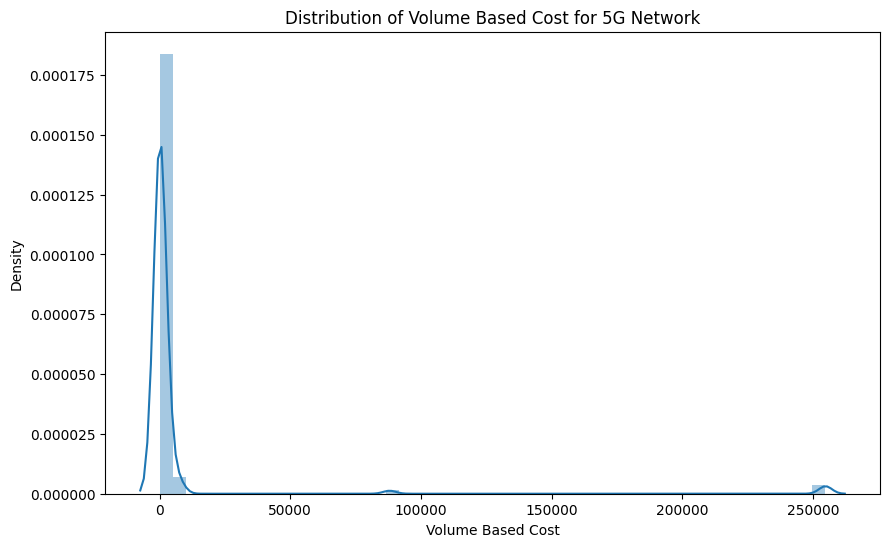

```python
# Plot distribution of aug_vbc_5g
plt.figure(figsize=(10,6))
sns.distplot(df['aug_vbc_5g'])

# Add title and labels to the plot
plt.title('Distribution of Volume Based Cost for 5G Network')
plt.xlabel('Volume Based Cost')
plt.ylabel('Density')
```

```python
# statistics for aug_vbc_5g
df['aug_vbc_5g'].describe()
```

```
count    653753.000000
mean       6145.362554
std       35849.567900
min           0.000000
25%           0.000000
50%         118.030000
75%         322.920000
max      254687.000000
Name: aug_vbc_5g, dtype: float64
```

**Hypotheses**:

- The distribution of aug_vbc_5g may have outliers.
- The max value of 254687 may not be a correct value.

```python
# Max value of aug_vbc_5g
df['aug_vbc_5g'].quantile([0.8,0.9,0.95,0.99])
```

```
0.80       363.630
0.90      1845.418
0.95      6470.342
0.99    254687.000
Name: aug_vbc_5g, dtype: float64
```

```python
# So we are having problems in 99th percentile
df['aug_vbc_5g'].quantile([0.99,0.999,0.9999])
```

```
0.9900    254687.0
0.9990    254687.0
0.9999    254687.0
Name: aug_vbc_5g, dtype: float64
```

```python
# Replace incorrect max value with NaN
df['aug_vbc_5g'].replace(254687.0, np.NaN, inplace=True)
```

```python
# Investigate max value of aug_vbc_5g
df['aug_vbc_5g'].quantile([0.99,0.999,0.9999])
```

```
0.9900     8028.1574
0.9990    87978.0000
0.9999    87978.0000
Name: aug_vbc_5g, dtype: float64
```

```python
# Replace incorrect max value with NaN
df['aug_vbc_5g'].replace(87978, np.NaN, inplace=True)
```

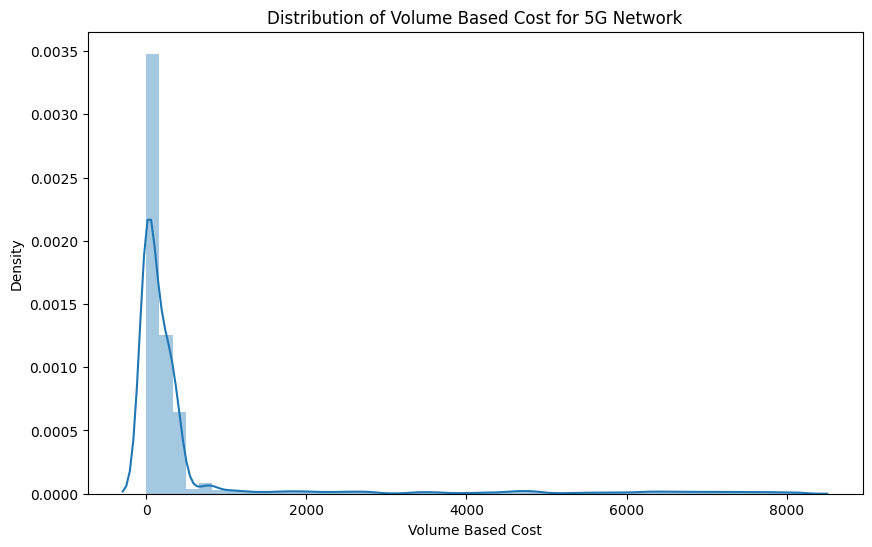

```python
# Plot distribution of aug_vbc_5g again
plt.figure(figsize=(10,6))
sns.distplot(df['aug_vbc_5g'])
# Add title and labels to the plot
plt.title('Distribution of Volume Based Cost for 5G Network')
plt.xlabel('Volume Based Cost')
plt.ylabel('Density')
```

```python
# Print updated quantiles for aug_vbc_5g
df['aug_vbc_5g'].quantile([0.8, 0.9, 0.99])
```

```
0.80     345.920
0.90     789.000
0.99    7387.188
Name: aug_vbc_5g, dtype: float64
```

```python
# Filter values > 5000 for aug_vbc_5g
df[df['aug_vbc_5g']>5000]
```

|  | Customer ID | Month of Joining | Month | zip_code | Gender | Age | Married | Dependents | Number of Dependents | Location ID | Service ID | state | county | timezone | area_codes | country | latitude | longitude | arpu | roam_ic | roam_og | loc_og_t2t | loc_og_t2m | loc_og_t2f | loc_og_t2c | std_og_t2t | std_og_t2m | std_og_t2f | std_og_t2c | … |
| --- | --- | --- | --- | --- | --- | --- | --- | --- | --- | --- | --- | --- | --- | --- | --- | --- | --- | --- | --- | --- | --- | --- | --- | --- | --- | --- | --- | --- | --- | --- |
| 7 | uqdtniwvxqzeu1 | 6 | 12 | 72566 | Male | NaN | No | No | 0.0 | qcvetdmalnkw1 | tkqnsqflrdatnqapsh1 | AR | Izard County | America/Chicago | 870.0 | US | 36.22 | -92.08 | 403.33 | 73.91 | 90.44 | 98.25 | 209.47 | 4.10 | 13.52 | 456.56 | 146.11 | 2.47 | 0.0 | … |
| 22 | zcpjiqpcepwze6 | 9 | 12 | 99014 | Male | 20.0 | Not Specified | Yes | 0.0 | ccpwvpbotmxq6 | mgziclzziovvirmftr6 | WA | Spokane County | America/Los_Angeles | 509.0 | US | 47.56 | -117.59 | 2360.29 | 1497.93 | 66.02 | 2544.26 | 684.87 | 51.38 | NaN | 1495.45 | NaN | 121.48 | NaN | … |
| 44 | nynydvvsfybbx10 | 7 | 12 | 94102 | Female | 39.0 | Not Specified | Not Specified | 2.0 | xogtkrpguqxx10 | enxzfoylgshzjshzsr10 | CA | San Francisco County | America/Los_Angeles | 415510.0 | US | 37.78 | -122.42 | -280.74 | 64.73 | 556.58 | 285.83 | NaN | 2.37 | NaN | 3810.45 | 109.61 | 44.07 | 0.0 | … |
| 45 | gxvosfxjewyla11 | 10 | 10 | 94502 | Female | 49.0 | Not Specified | Not Specified | 0.0 | ivytmikaadrw11 | hmgaoqynzbjnpixtlm11 | CA | Alameda County | America/Los_Angeles | 510.0 | US | 37.73 | -122.24 | 560.12 | 0.86 | 2801.95 | 222.99 | 93.80 | 0.95 | 9.63 | 87.46 | 159.32 | 150.04 | 0.0 | … |
| 54 | lkbosigyuaztq12 | 10 | 14 | 93714 | Female | 22.0 | Yes | No | 0.0 | tsutjfwdogsz12 | xfgudnbwrnolvixjdm12 | CA | Fresno County | America/Los_Angeles | 559.0 | US | 36.73 | -119.78 | 532.87 | 37.42 | 87.24 | 175.42 | 3835.39 | 6.83 | 6.70 | 1674.82 | 134.67 | NaN | 0.0 | … |
| ... | ... | ... | ... | ... | ... | ... | ... | ... | ... | ... | ... | ... | ... | ... | ... | ... | ... | ... | ... | ... | ... | ... | ... | ... | ... | ... | ... | ... | ... | … |
| 653576 | bayydffxltnbq162939 | 2 | 12 | 72410 | Not Specified | 60.0 | Yes | Yes | 0.0 | djjvyomwxpzr162939 | dzmfowmtkavchyyoqs162939 | AR | Lawrence County | America/Chicago | 870.0 | US | 35.89 | -91.08 | 319.31 | 26.82 | 1403.08 | 124.81 | 135.86 | 8.04 | 13.02 | 422.04 | 68.71 | 6.93 | 0.0 | … |
| 653582 | kifrnxonufxfz162941 | 8 | 8 | 91406 | Male | 60.0 | No | Not Specified | 0.0 | gcsruccxpcsv162941 | znckclwlobuoujscyy162941 | CA | Los Angeles County | America/Los_Angeles | 818.0 | US | 34.19 | -118.49 | 7806.46 | 773.60 | 1662.53 | 171.40 | 636.45 | 12.36 | 284.56 | NaN | 708.20 | 14.33 | 0.0 | … |
| 653587 | kifrnxonufxfz162941 | 8 | 13 | 91406 | Male | 60.0 | No | Not Specified | 0.0 | gcsruccxpcsv162941 | znckclwlobuoujscyy162941 | CA | Los Angeles County | America/Los_Angeles | 818.0 | US | 34.19 | -118.49 | 631.11 | NaN | 55.36 | 626.72 | NaN | 208.93 | 10.90 | NaN | 639.72 | NaN | NaN | … |
| 653648 | lzicibjioyxqt162958 | 3 | 5 | 91737 | Female | 30.0 | No | Not Specified | 0.0 | yifnvvazrvte162958 | enhuvxisakwoxzkmxy162958 | CA | San Bernardino County | America/Los_Angeles | 909.0 | US | 34.15 | -117.58 | -227.38 | 0.00 | 0.00 | 0.00 | 0.00 | 0.00 | 0.00 | 0.00 | 0.00 | 0.00 | 0.0 | … |
| 653678 | ncqmlcpkjbzza162965 | 5 | 7 | 95556 | Not Specified | 55.0 | Yes | No | NaN | lprfcbpyuuzx162965 | ftqhurnkdxqethhcij162965 | CA | Humboldt County | America/Los_Angeles | Unknown | US | 41.31 | -123.61 | 598.10 | 18.09 | 60.98 | 293.76 | 161.29 | 2.57 | 10.56 | 624.38 | 268.43 | 1.27 | 0.0 | … |

23785 rows × 74 columns

**Observations**:

- The maximum value of 254687 was replaced with NaN due to it being an incorrect value.
- One additional incorrect value of 87978 was also replaced with NaN.
- The 99th percentile value was changed to 7387.188 after replacing the incorrect values.
- Values greater than 5000 were found to be valid values that may require transformations or normalization later.

### **Churn Value**

```python
# Count the values of churned customers
df['Churn Value'].value_counts(dropna=False)
```

```
0    623888
1     29865
Name: Churn Value, dtype: int64
```

There are no null values in the column "Churn Value".

```python
# Normalizing value counts
df['Churn Value'].value_counts(normalize=True)
```

```
0    0.954318
1    0.045682
Name: Churn Value, dtype: float64
```

```python
# Unique customer IDs and their churn values
cust_churn = df[['Customer ID', 'Churn Value']].drop_duplicates()

# Calculate the percentage of customers who churned out
churn_percent = round((cust_churn['Churn Value'].value_counts()[1] / len(cust_churn)) * 100, 2)

print("Percentage of customers who churned out:", churn_percent, "%")
```

```
Percentage of customers who churned out: 24.72 %
```

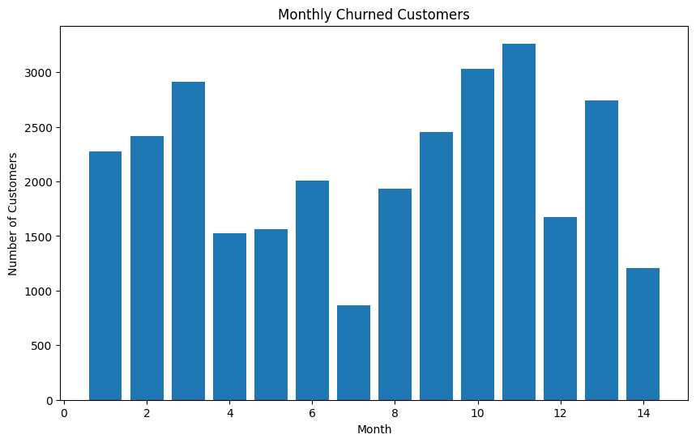

```python
# Convert Month column to integer and filter Churn Value =1
churn_monthly = df[df['Churn Value'] == 1]['Month'].astype(int).value_counts().sort_index()

# Plotting bar chart
plt.figure(figsize=(10,6))
plt.bar(churn_monthly.index, churn_monthly.values)
plt.title('Monthly Churned Customers')
plt.xlabel('Month')
plt.ylabel('Number of Customers')
plt.show()
```

**Observation**:

- From the plot, we can see that there is a gradual increase in the number of churned customers from month 7 to month 11.
- Month 11 has the highest number of churned customers, indicating that there may have been some issue with the services provided during that month that led to customers leaving the network. We will have to analyze this further.

### **Offer**

```python
# Count the unique values in Offer column
df['offer'].value_counts(dropna=False)
```

```
NaN    494644
D       16162
C       16153
A       15915
J       15893
B       15871
I       15860
H       15855
E       15833
F       15789
G       15778
Name: offer, dtype: int64
```

**Observation**: There are a lot of null values in the offer column.

**Hypotheses**:

- It's possible that the null values in the offer column are due to customers not being eligible for any offers.
- However, it's also possible that there was an error in recording the data or that some customers were missed when the offers were being given out.
- We can investigate further by looking at the distribution of offer types and see if there are any patterns based on customer demographics or behavior.

```python
# Filling Nulls with No Offer
df['offer']=df['offer'].fillna('No Offer')
```

```python
# Check the value counts again
df[df['Churn Value']==1]['offer'].value_counts()
```

```
No Offer    15292
D            1484
J            1483
H            1477
C            1470
I            1468
A            1464
F            1459
B            1441
E            1418
G            1409
Name: offer, dtype: int64
```

**Observation**:

- If the offers are distributed in the same way, it suggests that the company has not targeted any specific group of customers with special offers.
- This could mean that the company is more focused on providing equal benefits to all customers rather than targeting specific segments.
- We can explore the relationship between the offers and customer data, such as age, gender, location, and usage patterns. This could help identify any patterns or preferences among customers that could help with the future marketing strategies.
- Analyzing the impact of the offers on customer churn could help the company optimize their promotional campaigns.

### **Referred a Friend and Number of Referrals**

```python
# Count the values if a customer referred the company's services to a friend
df['Referred a Friend'].value_counts(dropna=False)
```

```
Yes    525449
No     128304
Name: Referred a Friend, dtype: int64
```

```python
# Here are the number of referrals
df['Number of Referrals'].value_counts(dropna=False)
```

```
0.0     167747
1.0      60907
4.0      50033
11.0     48778
7.0      48707
8.0      48136
6.0      46975
3.0      44500
10.0     40923
5.0      36908
2.0      33749
9.0      26003
NaN        387
Name: Number of Referrals, dtype: int64
```

**Observation**:

- There are some null values. We can add them later.
- It will be interesting to see both the column of friends referred and the number of referrals together.

```python
# Count the values of Referred a Friend and Number of Referrals
df[['Referred a Friend','Number of Referrals']].value_counts(dropna=False)
```

```
Referred a Friend  Number of Referrals
No                 0.0                    111753
Yes                0.0                     55994
                   1.0                     51002
                   4.0                     50033
                   11.0                    48778
                   7.0                     48707
                   8.0                     48136
                   6.0                     46975
                   3.0                     41996
                   10.0                    40923
                   5.0                     36908
                   2.0                     29607
                   9.0                     26003
No                 1.0                      9905
                   2.0                      4142
                   3.0                      2504
Yes                NaN                       387
dtype: int64
```

### **Phone Service**

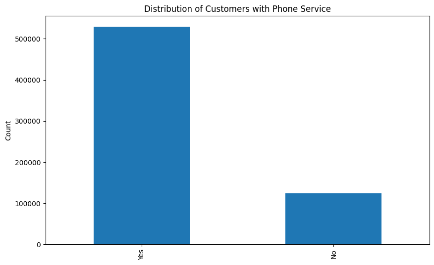

```python
# Count the value of customers with and without phone service
plt.figure(figsize=(10,6))
df['Phone Service'].value_counts(dropna=False).plot.bar()
plt.title("Distribution of Customers with Phone Service")
plt.ylabel("Count")
plt.show()
```

**Observation**:

- Phone Service is a popular choice among customers, with over 5 lakh customers opting for it over the 14-month period. This suggests that it is an important service for the company to continue offering and investing in.
- It would be interesting to explore the demographics and usage patterns of customers who opted for Phone Service versus those who did not. This could help the company better understand the needs and preferences of its customer base.

### **Internet Service and Internet Type**

```python
# Count the values of the customers with and without Internet Service
df['Internet Service'].value_counts(dropna=False)
```

```
Yes    398863
No     254890
Name: Internet Service, dtype: int64
```

**Observation**:

- About 4L customers (not unique) have opted for internet service over 14 months.
- To gain more insights, we can combine this observation with other columns like churn value, total charges, contract type, payment method, and monthly charges, as mentioned earlier. This can help us understand the behavior and preferences of customers who have opted for internet service and identify potential areas for improvement or upselling.

```python
# Count the Internet Type values
df['Internet Type'].value_counts(dropna=False)
```

```
NaN            217332
Fiber Optic    134991
Cable          112100
None           107918
DSL             81412
Name: Internet Type, dtype: int64
```

**Observation**:

- There are four types of internet services offered: Fiber Optic, Cable, DSL, and None.
- Majority of customers have opted for Fiber Optic and Cable internet services.
- There may be cases where the internet service is yes but the internet type is not specified (NaN values).
- There may be cases where the internet service is no but the internet type is specified (which does not make sense).

```python
# Count the values of internet service and type together
df[['Internet Service','Internet Type']].value_counts(dropna=False)
```

```
Internet Service  Internet Type
No                NaN              217332
Yes               Fiber Optic      125590
                  Cable            108372
                  None              89098
                  DSL               75803
No                None              18820
                  Fiber Optic        9401
                  DSL                5609
                  Cable              3728
dtype: int64
```

**Observation**:

- As these are not unique values , they are monthly values for each customer we'll have to see which customers had internet service for that month or not.
- Some customers have said yes to having internet service but their internet type is none.
- It could mean that the customer has not used the internet during that month. However, it could also mean that there is missing data or the customer is using an unknown type of internet service.
- We can check if there is any usage data available for the customer during that month. If there is usage data available, we can assume that the customer has used the internet and fill the missing value with the most common internet type for that customer. If there is no usage data available, we can leave the value as None.

### **Unlimited Data**

```python
# Count the values of the Unlimited Data column
df['Unlimited Data'].value_counts(dropna=False)
```

```
Yes     352341
No      290309
None     11103
Name: Unlimited Data, dtype: int64
```

**Observation**:

- The majority of the customers have subscribed to the Unlimited Data plan across 14 months.

### **Streaming Movies**

```python
# Count the values of the streaming movies column
df['Streaming Movies'].value_counts(dropna=False)
```

```
No     334570
Yes    319183
Name: Streaming Movies, dtype: int64
```

**Observation**:

- The distribution is almost similar across 14 months.

### **Streaming TV**

```python
# Count the values of the streaming TV column
df['Streaming TV'].value_counts(dropna=False)
```

```
No     331747
Yes    322006
Name: Streaming TV, dtype: int64
```

**Observation**:

- The distribution is almost similar across 14 months.

### **Streaming Music**

```python
# Count the values of the streaming movies column
df['Streaming Music'].value_counts(dropna=False)
```

```
No     357691
Yes    296062
Name: Streaming Music, dtype: int64
```

**Observation**:

- The majority do not have a music streaming service across 14 months.

### **Streaming Data Consumption**

```python
# Check statistics
df['Streaming Data Consumption'].describe()
```

```
count    653753.000000
mean         27.574284
std          26.349552
min           0.000000
25%           2.000000
50%          20.000000
75%          49.000000
max          85.000000
Name: Streaming Data Consumption, dtype: float64
```

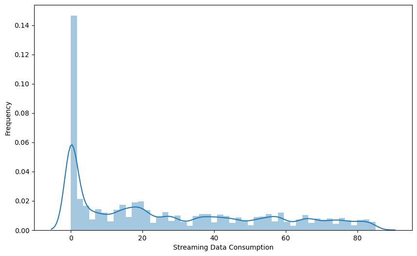

```python
# Plot
plt.figure(figsize=(10,6))
sns.distplot(df['Streaming Data Consumption'])
plt.xlabel('Streaming Data Consumption')
plt.ylabel('Frequency')
plt.show()
```

```python
# check null values
df['Streaming Data Consumption'].isna().sum()
```

```
0
```

**Observation**:

- The minimum value is 0 GB, indicating that some customers did not consume any streaming data during the month, while the maximum value is 85 GB.
- The highly right skewed distribution of streaming consumption data indicates that a small proportion of customers are consuming a disproportionately large amount of streaming data.
- From a business perspective, this information could be used to tailor marketing and pricing strategies to target heavy streaming users and to offer them plans that meet their needs.
- We can further explore how streaming data consumption relates to other columns such as "Streaming Movies" or "Streaming TV" to gain additional insights into customer behavior and preferences with respect to churn value and satisfaction score.
- There are no null values in the column.

### **Online Security**

```python
# Check the counts of Online Security column
df['Online Security'].value_counts(dropna=False)
```

```
No     564647
Yes     89106
Name: Online Security, dtype: int64
```

**Observation**:

- The majority of customers did not have Online Security through the months.

### **Online Backup**

```python
# Check the counts of Online Backup Column
df['Online Backup'].value_counts(dropna=False)
```

```
No     437242
Yes    216511
Name: Online Backup, dtype: int64
```

**Observation**:

- The majority of customers did not have Online Backup through the months.

### **Device Protection Plan**

```python
# Count the number of unique values in the column
df['Device Protection Plan'].value_counts(dropna=False)
```

```
No     327748
Yes    326005
Name: Device Protection Plan, dtype: int64
```

**Observation**:

- The distribution is similar through the months.

### **Premium Tech Support**

```python
# Count the unique values of Premium Tech Support
df['Premium Tech Support'].value_counts(dropna=False)
```

```
No     485906
Yes    167847
Name: Premium Tech Support, dtype: int64
```

**Observation**:

- The majority of customers did not have Premium Tech Support through the months.

### **Payment Method**

```python
# Count the unique values of payment method
df['Payment Method'].value_counts(dropna=False)
```

```
Bank Withdrawal    374219
Credit Card        231050
Wallet Balance      48484
Name: Payment Method, dtype: int64
```

**Observation**:

- Bank withdrawal is the most popular payment method among customers.
- There is a significant difference in the number of customers using bank withdrawal compared to credit card or wallet balance.

### **Status ID**

```python
# Total null values in Status ID
df['Status ID'].isna().sum()
```

```
0
```

```python
# Number of Unique Status IDs
df['Status ID'].nunique()
```

```
653753
```

Each payment made by a consumer has a unique status Id.

### **Customer Satisfaction Score**

```python
# # Count the values each satisfaction score
df['Satisfaction Score'].value_counts(dropna=False)
```

```
3    258752
4    133473
5    106567
1    105539
2     49422
Name: Satisfaction Score, dtype: int64
```

**Observation**:

- Most of the customers have rated their satisfaction with a score of 3.
- A significant number of customers have rated their satisfaction with scores of 1 and 2.
- The satisfaction score is an important metric to measure customer satisfaction and loyalty.
- It is important to investigate why a significant number of customers have rated their satisfaction with lower scores, i.e., 1 and 2.
- Based on the insights obtained from other columns, such as the service type, internet type, and device protection plan, we can analyze whether there is a correlation between these variables and customer satisfaction.

### **Churn Category**

```python
# Count the values of different churn categories
df['Churn Category'].value_counts(dropna=False)
```

```
NaN                624017
Support              7538
Dissatisfaction      6001
Competitor           5974
Price                4381
Other                4356
bcvjhdjcb            1190
Attitude              296
Name: Churn Category, dtype: int64
```

**Observation**:

- The "Churn Category" column has a high percentage of missing values, with NaN accounting for the majority of the values.
- Let's investigate the null values.

```python
# Let's see the churn value for all those observations where churn category is null
df[df['Churn Category'].isna()]['Churn Value'].value_counts(dropna=False)
```

```
0    622748
1      1269
Name: Churn Value, dtype: int64
```

Hence, if a customer is not churned, we can simply mark it as not applicable and mark others as unknown.

```python
# Filling null values of churn category as not applicatable where customers did not churn
df.loc[(df['Churn Category'].isna())&(df['Churn Value']==0),'Churn Category']='Not Applicable'
```

```python
# Filling the churn category as Unknown where churn value was 1
checkpoint('fcTel1')
df.loc[(df['Churn Category'].isna())&(df['Churn Value']==1),'Churn Category']='Unknown'
```

```python
# Check the counts again
df['Churn Category'].value_counts(dropna=False)
```

```
Not Applicable     622748
Support              7538
Dissatisfaction      6001
Competitor           5974
Price                4381
Other                4356
Unknown              1269
bcvjhdjcb            1190
Attitude              296
Name: Churn Category, dtype: int64
```

### **Churn Reason**

```python
# Count the values of different churn reasons
df['Churn Reason'].value_counts(dropna=False)
```

```
NaN                                          623986
43tgeh                                         1796
Service dissatisfaction                        1555
Lack of self-service on Website                1547
Attitude of support person                     1535
Moved                                          1482
Competitor offered more data                   1481
Competitor had better devices                  1458
Poor expertise of online support               1445
Product dissatisfaction                        1417
Attitude of service provider                   1410
Long distance charges                          1389
Lack of affordable download/upload speed       1381
Competitor made better offer                   1358
Price too high                                 1358
Competitor offered higher download speeds      1352
Poor expertise of phone support                1330
Network reliability                            1311
Extra data charges                             1310
Deceased                                       1289
Don't know                                     1288
Limited range of services                      1275
Name: Churn Reason, dtype: int64
```

**Observation**:

- The "Churn Reason" column has a high percentage of missing values.
- Let's investigate the null values.

There are some null and absurd values in the churn reason column.

```python
# Count of null churn reasons and their churn value
df[(df['Churn Reason'].isna())]['Churn Value'].value_counts(dropna=False)
```

```
0    622169
1      1817
Name: Churn Value, dtype: int64
```

Anytime a customer is not churned, we can simply mark it as not applicable and mark others as unknown.

```python
# Filling the churn reason as not applicable where churn value was 0
df.loc[(df['Churn Reason'].isna())&(df['Churn Value']==0),'Churn Reason']='Not Applicable'
```

```python
# Filling the churn reason as Unknown where churn value was 1
df.loc[(df['Churn Reason'].isna())&(df['Churn Value']==1),'Churn Reason']='Unknown'
```

```python
# Check the value counts in the Churn Reason again
df['Churn Reason'].value_counts(dropna=False)
```

```
Not Applicable                               622169
Unknown                                        1817
43tgeh                                         1796
Service dissatisfaction                        1555
Lack of self-service on Website                1547
Attitude of support person                     1535
Moved                                          1482
Competitor offered more data                   1481
Competitor had better devices                  1458
Poor expertise of online support               1445
Product dissatisfaction                        1417
Attitude of service provider                   1410
Long distance charges                          1389
Lack of affordable download/upload speed       1381
Competitor made better offer                   1358
Price too high                                 1358
Competitor offered higher download speeds      1352
Poor expertise of phone support                1330
Network reliability                            1311
Extra data charges                             1310
Deceased                                       1289
Don't know                                     1288
Limited range of services                      1275
Name: Churn Reason, dtype: int64
```

### **Customer Status**

```python
# Check the unique values
df['Customer Status'].unique()
```

```
array(['Churned', 'Stayed'], dtype=object)
```

```python
# Check customer status and churn values together
df[['Customer Status','Churn Value']].value_counts(dropna=False)
```

```
Customer Status  Churn Value
Stayed           0              623888
Churned          1               29865
dtype: int64
```

Everything seems good here!

### **Customer Call Usage Analysis**

```python
# All columns
df.columns
```

```
Index(['Customer ID', 'Month of Joining', 'Month', 'zip_code', 'Gender', 'Age',
       'Married', 'Dependents', 'Number of Dependents', 'Location ID',
       'Service ID', 'state', 'county', 'timezone', 'area_codes', 'country',
       'latitude', 'longitude', 'arpu', 'roam_ic', 'roam_og', 'loc_og_t2t',
       'loc_og_t2m', 'loc_og_t2f', 'loc_og_t2c', 'std_og_t2t', 'std_og_t2m',
       'std_og_t2f', 'std_og_t2c', 'isd_og', 'spl_og', 'og_others',
       'loc_ic_t2t', 'loc_ic_t2m', 'loc_ic_t2f', 'std_ic_t2t', 'std_ic_t2m',
       'std_ic_t2f', 'std_ic_t2o', 'spl_ic', 'isd_ic', 'ic_others',
       'total_rech_amt', 'total_rech_data', 'vol_4g', 'vol_5g', 'arpu_5g',
       'arpu_4g', 'night_pck_user', 'fb_user', 'aug_vbc_5g', 'Churn Value',
       'Referred a Friend', 'Number of Referrals', 'Phone Service',
       'Multiple Lines', 'Internet Service', 'Internet Type',
       'Streaming Data Consumption', 'Online Security', 'Online Backup',
       'Device Protection Plan', 'Premium Tech Support', 'Streaming TV',
       'Streaming Movies', 'Streaming Music', 'Unlimited Data',
       'Payment Method', 'Status ID', 'Satisfaction Score', 'Churn Category',
       'Churn Reason', 'Customer Status', 'offer'],
      dtype='object')
```

```python
# Setting customer id and month as index
df=df.set_index(['Customer ID','Month'])
```

```python
# Selecting specific columns to check the customer call usage
df_call_usage=df[['Month of Joining','roam_ic', 'roam_og', 'loc_og_t2t',
       'loc_og_t2m', 'loc_og_t2f', 'loc_og_t2c', 'std_og_t2t', 'std_og_t2m',
       'std_og_t2f', 'std_og_t2c', 'isd_og', 'spl_og', 'og_others',
       'loc_ic_t2t', 'loc_ic_t2m', 'loc_ic_t2f', 'std_ic_t2t', 'std_ic_t2m',
       'std_ic_t2f', 'std_ic_t2o', 'spl_ic', 'isd_ic', 'ic_others',
       'total_rech_amt','Phone Service']]
```

```python
# Top three rows
df_call_usage.head(3)
```

| Customer ID | Month | Month of Joining | roam_ic | roam_og | loc_og_t2t | loc_og_t2m | loc_og_t2f | loc_og_t2c | std_og_t2t | std_og_t2m | std_og_t2f | std_og_t2c | isd_og | spl_og | og_others | loc_ic_t2t | loc_ic_t2m | loc_ic_t2f | std_ic_t2t | std_ic_t2m | std_ic_t2f | std_ic_t2o | spl_ic | isd_ic | ic_others | total_rech_amt | Phone Service |
| --- | --- | --- | --- | --- | --- | --- | --- | --- | --- | --- | --- | --- | --- | --- | --- | --- | --- | --- | --- | --- | --- | --- | --- | --- | --- | --- | --- |
| hthjctifkiudi0 | 1 | 1 | 18.88 | 78.59 | 280.32 | 30.97 | 5.71 | 1.79 | 25.71 | 175.56 | 0.47 | 0.0 | 5.11 | 0.65 | 13.99 | 121.51 | 168.40 | 67.61 | 115.69 | 52.22 | 18.71 | 0.0 | 0.26 | 11.53 | 46.42 | 18 | Yes |
| uqdtniwvxqzeu1 | 6 | 6 | 69.46 | 72.08 | 255.73 | 148.80 | 30.00 | 7.61 | 308.29 | 265.20 | 10.82 | 0.0 | 1.23 | 905.51 | 1.69 | 212.93 | 155.19 | 29.04 | 9.15 | 38.89 | 0.84 | 0.0 | 0.05 | 32.51 | 25.53 | 1183 | Yes |
|  | 7 | 6 | 1012.60 | 115.26 | 52.95 | NaN | 103.28 | 15.71 | 244.20 | 15.19 | NaN | NaN | 13.14 | 455.15 | 115.63 | 121.80 | 699.39 | 44.49 | 83.59 | 914.70 | 13.25 | 0.0 | 0.06 | 13.05 | 5.62 | 295 | Yes |

```python
# There are a lot of null values
df_call_usage.describe()
```

|  | Month of Joining | roam_ic | roam_og | loc_og_t2t | loc_og_t2m | loc_og_t2f | loc_og_t2c | std_og_t2t | std_og_t2m | std_og_t2f | std_og_t2c | isd_og | spl_og | og_others | loc_ic_t2t | loc_ic_t2m | loc_ic_t2f | std_ic_t2t | std_ic_t2m | std_ic_t2f | std_ic_t2o | spl_ic | isd_ic | ic_others |
| --- | --- | --- | --- | --- | --- | --- | --- | --- | --- | --- | --- | --- | --- | --- | --- | --- | --- | --- | --- | --- | --- | --- | --- | --- |
| count | 653753.000000 | 6.249240e+05 | 6.334710e+05 | 6.260620e+05 | 6.257440e+05 | 5.864870e+05 | 6.305460e+05 | 6.165360e+05 | 6.077260e+05 | 6.263330e+05 | 5.427680e+05 | 6.122130e+05 | 5.596970e+05 | 6.322620e+05 | 618673.000000 | 626915.000000 | 629922.000000 | 596420.000000 | 627547.000000 | 635174.000000 | 570165.0 | 620476.000000 | 570988.000000 | 613198.000000 |
| mean | 5.823574 | 3.695572e+04 | 3.629550e+04 | 3.545171e+04 | 3.659867e+04 | 3.730951e+04 | 3.423369e+04 | 3.562221e+04 | 3.644849e+04 | 3.465084e+04 | 4.203332e+04 | 3.542208e+04 | 3.930345e+04 | 3.584864e+04 | 791.399134 | 672.287159 | 315.452390 | 314.727407 | 290.950402 | 120.796443 | 0.0 | 0.233584 | 170.837105 | 127.687898 |
| std | 2.855148 | 5.633568e+05 | 5.579342e+05 | 5.472752e+05 | 5.573928e+05 | 5.673674e+05 | 5.435927e+05 | 5.510383e+05 | 5.588584e+05 | 5.468664e+05 | 6.024441e+05 | 5.526578e+05 | 5.822548e+05 | 5.557578e+05 | 1212.105552 | 994.667177 | 483.716646 | 611.683476 | 438.097905 | 185.391565 | 0.0 | 0.438172 | 384.665897 | 289.060700 |
| min | 1.000000 | 0.000000e+00 | 0.000000e+00 | 0.000000e+00 | 0.000000e+00 | 0.000000e+00 | 0.000000e+00 | 0.000000e+00 | 0.000000e+00 | 0.000000e+00 | 0.000000e+00 | 0.000000e+00 | 0.000000e+00 | 0.000000e+00 | 0.000000 | 0.000000 | 0.000000 | 0.000000 | 0.000000 | 0.000000 | 0.0 | 0.000000 | 0.000000 | 0.000000 |
| 25% | 3.000000 | 1.249000e+01 | 1.989000e+01 | 4.239000e+01 | 3.428000e+01 | 1.540000e+00 | 2.110000e+00 | 4.159000e+01 | 3.027000e+01 | 1.570000e+00 | 0.000000e+00 | 3.980000e+00 | 4.320000e+00 | 4.590000e+00 | 80.970000 | 80.750000 | 34.890000 | 38.750000 | 30.900000 | 12.090000 | 0.0 | 0.040000 | 23.640000 | 19.100000 |
| 50% | 6.000000 | 4.929000e+01 | 7.475000e+01 | 1.670200e+02 | 1.319800e+02 | 7.230000e+00 | 8.440000e+00 | 1.662000e+02 | 1.251500e+02 | 6.490000e+00 | 0.000000e+00 | 1.704000e+01 | 2.203000e+01 | 1.857000e+01 | 162.470000 | 161.520000 | 69.495000 | 77.290000 | 62.110000 | 24.260000 | 0.0 | 0.080000 | 47.030000 | 38.070000 |
| 75% | 8.000000 | 1.118400e+02 | 1.336800e+02 | 2.993900e+02 | 4.701500e+02 | 1.290000e+01 | 1.478000e+01 | 2.999400e+02 | 2.272800e+02 | 3.525000e+01 | 0.000000e+00 | 3.014000e+01 | 3.981000e+01 | 9.343000e+01 | 1039.430000 | 866.780000 | 408.410000 | 115.550000 | 380.180000 | 165.410000 | 0.0 | 0.140000 | 70.610000 | 57.190000 |
| max | 12.000000 | 8.787978e+06 | 8.787978e+06 | 8.787978e+06 | 8.787978e+06 | 8.787978e+06 | 8.787978e+06 | 8.787978e+06 | 8.787978e+06 | 8.787978e+06 | 8.787978e+06 | 8.787978e+06 | 8.787978e+06 | 8.787978e+06 | 4363.950000 | 3783.530000 | 1872.340000 | 2527.070000 | 1619.680000 | 663.930000 | 0.0 | 2.330000 | 1624.530000 | 1344.130000 |

**Observations**:

- 'roam_ic', 'roam_og', 'loc_og_t2t','loc_og_t2m', 'loc_og_t2f', 'loc_og_t2c', 'std_og_t2t', 'std_og_t2m','std_og_t2f', 'std_og_t2c', 'isd_og', 'spl_og', 'og_others' columns have max value as

8.787978e+06.

- Some columns seem to have null values.
- The column total_rech_amt and Phone Service are missing from this table.

```python
# Let's check how many null values are present where calling plan is there
df_call_usage[df_call_usage['Phone Service']=='Yes'].isna().sum()
```

```
Month of Joining         0
roam_ic              28829
roam_og              20282
loc_og_t2t           27691
loc_og_t2m           28009
loc_og_t2f           67266
loc_og_t2c           23207
std_og_t2t           37217
std_og_t2m           46027
std_og_t2f           27420
std_og_t2c          110985
isd_og               41540
spl_og               94056
og_others            21491
loc_ic_t2t           28366
loc_ic_t2m           21701
loc_ic_t2f           19300
std_ic_t2t           46343
std_ic_t2m           21173
std_ic_t2f           14969
std_ic_t2o           67623
spl_ic               26873
isd_ic               66986
ic_others            32766
total_rech_amt           0
Phone Service            0
dtype: int64
```

```python
# Lets check how many % values are missing
df_call_usage[df_call_usage['Phone Service']=='Yes'].isna().sum()/df_call_usage.shape[0]
```

```
Month of Joining    0.000000
roam_ic             0.044098
roam_og             0.031024
loc_og_t2t          0.042357
loc_og_t2m          0.042843
loc_og_t2f          0.102892
loc_og_t2c          0.035498
std_og_t2t          0.056928
std_og_t2m          0.070404
std_og_t2f          0.041942
std_og_t2c          0.169766
isd_og              0.063541
spl_og              0.143871
og_others           0.032873
loc_ic_t2t          0.043389
loc_ic_t2m          0.033194
loc_ic_t2f          0.029522
std_ic_t2t          0.070888
std_ic_t2m          0.032387
std_ic_t2f          0.022897
std_ic_t2o          0.103438
spl_ic              0.041106
isd_ic              0.102464
ic_others           0.050120
total_rech_amt      0.000000
Phone Service       0.000000
dtype: float64
```

```python
#lets check how many null values are present where calling plan is not there
df_call_usage[df_call_usage['Phone Service']=='No'].isna().sum()
```

```
Month of Joining        0
roam_ic                 0
roam_og                 0
loc_og_t2t              0
loc_og_t2m              0
loc_og_t2f              0
loc_og_t2c              0
std_og_t2t              0
std_og_t2m              0
std_og_t2f              0
std_og_t2c              0
isd_og                  0
spl_og                  0
og_others               0
loc_ic_t2t           6714
loc_ic_t2m           5137
loc_ic_t2f           4531
std_ic_t2t          10990
std_ic_t2m           5033
std_ic_t2f           3610
std_ic_t2o          15965
spl_ic               6404
isd_ic              15779
ic_others            7789
total_rech_amt          0
Phone Service           0
dtype: int64
```

```python
# Lets check how many % values are missing
df_call_usage[df_call_usage['Phone Service']=='No'].isna().sum()/df_call_usage.shape[0]
```

```
Month of Joining    0.000000
roam_ic             0.000000
roam_og             0.000000
loc_og_t2t          0.000000
loc_og_t2m          0.000000
loc_og_t2f          0.000000
loc_og_t2c          0.000000
std_og_t2t          0.000000
std_og_t2m          0.000000
std_og_t2f          0.000000
std_og_t2c          0.000000
isd_og              0.000000
spl_og              0.000000
og_others           0.000000
loc_ic_t2t          0.010270
loc_ic_t2m          0.007858
loc_ic_t2f          0.006931
std_ic_t2t          0.016811
std_ic_t2m          0.007699
std_ic_t2f          0.005522
std_ic_t2o          0.024421
spl_ic              0.009796
isd_ic              0.024136
ic_others           0.011914
total_rech_amt      0.000000
Phone Service       0.000000
dtype: float64
```

We will impute all these values later!

```python
# lets find datatypes of all the columns
df_call_usage.dtypes
```

```
Month of Joining      int64
roam_ic             float64
roam_og             float64
loc_og_t2t          float64
loc_og_t2m          float64
loc_og_t2f          float64
loc_og_t2c          float64
std_og_t2t          float64
std_og_t2m          float64
std_og_t2f          float64
std_og_t2c          float64
isd_og              float64
spl_og              float64
og_others           float64
loc_ic_t2t          float64
loc_ic_t2m          float64
loc_ic_t2f          float64
std_ic_t2t          float64
std_ic_t2m          float64
std_ic_t2f          float64
std_ic_t2o          float64
spl_ic              float64
isd_ic              float64
ic_others           float64
total_rech_amt       object
Phone Service        object
dtype: object
```

Observe that `total_rech_amt` is object but according to data dictionary it is a float.

```python
# There are 124570 rows containg no calling plan
df_call_usage['Phone Service'].value_counts()
```

```
Yes    529183
No     124570
Name: Phone Service, dtype: int64
```

```python
# Counts of unique values in total rech amount
df_call_usage['total_rech_amt'].value_counts()
```

```
0        106254
989        7432
98769      6245
e01        2507
0.1        2485
          ...
8047          1
4616          1
7822          1
7747          1
8120          1
Name: total_rech_amt, Length: 11899, dtype: int64
```

```python
# Replace the invalid value
df_call_usage.loc[df['total_rech_amt']=='e01','total_rech_amt']=10
```

Let's now change the column to a numeric datatype.

```python
# Changing the column back to numeric data type
df_call_usage['total_rech_amt']=pd.to_numeric(df_call_usage['total_rech_amt'])
```

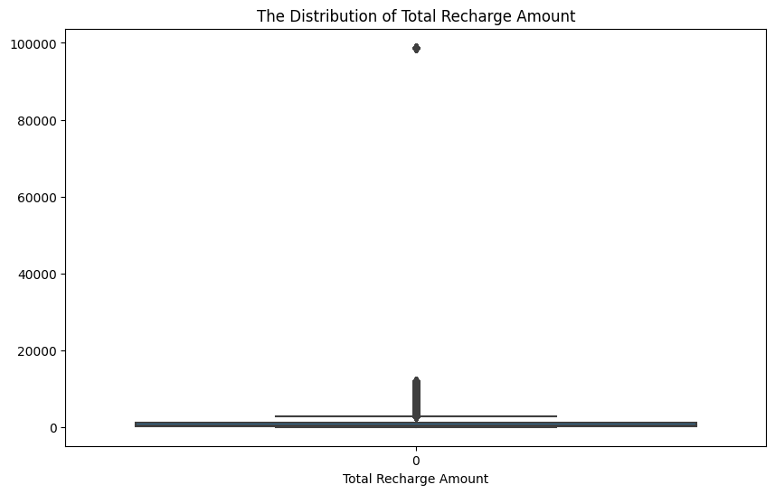

```python
# Plot the the distribution using Box plot
plt.figure(figsize=(10,6))
sns.boxplot(df_call_usage['total_rech_amt'])
plt.title("The Distribution of Total Recharge Amount")
plt.xlabel("Total Recharge Amount")
plt.show()
```

It is worth noting that there are certain customers around 100,000. Let's see how many of these customers there are.

```python
# Check the quantiles
df_call_usage['total_rech_amt'].quantile([0.1, 0.5,0.75 ,0.9,0.97,0.99,0.999])
```

```
0.100        0.0
0.500      400.0
0.750     1158.0
0.900     7377.0
0.970    10939.0
0.990    11875.0
0.999    98769.0
Name: total_rech_amt, dtype: float64
```

Observe that for 0.990 percentlile the value is greater 11875. Let's check how many customer are there with more recharge amount.

```python
# Filter the dataframe
df_call_usage[df_call_usage['total_rech_amt']>11875.0]
```

| Customer ID | Month | Month of Joining | roam_ic | roam_og | loc_og_t2t | loc_og_t2m | loc_og_t2f | loc_og_t2c | std_og_t2t | std_og_t2m | std_og_t2f | std_og_t2c | isd_og | spl_og | og_others | loc_ic_t2t | loc_ic_t2m | loc_ic_t2f | std_ic_t2t | std_ic_t2m | std_ic_t2f | std_ic_t2o | spl_ic | isd_ic | ic_others | total_rech_amt | Phone Service |
| --- | --- | --- | --- | --- | --- | --- | --- | --- | --- | --- | --- | --- | --- | --- | --- | --- | --- | --- | --- | --- | --- | --- | --- | --- | --- | --- | --- |
| lkbosigyuaztq12 | 10 | 10 | 0.0 | 0.0 | 0.0 | 0.0 | 0.0 | 0.0 | 0.0 | 0.0 | 46254.0 | 0.0 | 0.0 | 0.0 | 0.0 | 192.19 | 120.79 | 68.37 | 57.01 | 22.29 | 28.05 | 0.0 | 0.10 | 56.95 | 1.77 | 98769.0 | No |
| nfhyvxuubmklt23 | 7 | 6 | 68.0 | 0.0 | 0.0 | 68.0 | 45.0 | 0.0 | 0.0 | 0.0 | 46254.0 | 0.0 | 0.0 | 0.0 | 45.0 | 1166.10 | 43.26 | 64.48 | 107.55 | 72.08 | 25.65 | 0.0 | 0.05 | 73.34 | 32.82 | 98769.0 | No |
| kzxgwhhdwzqop26 | 8 | 8 | 0.0 | 0.0 | 0.0 | 0.0 | 0.0 | 0.0 | 0.0 | 0.0 | 0.0 | 0.0 | 0.0 | 0.0 | 0.0 | 204.77 | 164.94 | 40.57 | 20.74 | 56.17 | 28.37 | 0.0 | 0.11 | 73.75 | 19.31 | 98769.0 | No |
| mzhzpzzpqoqab40 | 6 | 6 | 0.0 | 0.0 | 0.0 | 0.0 | 0.0 | 68.0 | 8787978.0 | 0.0 | 0.0 | 0.0 | 0.0 | 0.0 | 0.0 | 2060.25 | 33.00 | 28.18 | 36.61 | 21.09 | 32.55 | 0.0 | 0.11 | 48.86 | 14.85 | 98769.0 | No |
| hlknupiesduin44 | 14 | 5 | 8787978.0 | 0.0 | 0.0 | 46254.0 | 0.0 | 0.0 | 0.0 | 0.0 | 0.0 | 0.0 | 0.0 | 46254.0 | 0.0 | 127.40 | 36.26 | 44.32 | 102.66 | 46.65 | 15.00 | 0.0 | 0.01 | 51.17 | 66.28 | 98769.0 | No |
| ... | ... | ... | ... | ... | ... | ... | ... | ... | ... | ... | ... | ... | ... | ... | ... | ... | ... | ... | ... | ... | ... | ... | ... | ... | ... | ... | ... |
| zgcwbliyezhkm162866 | 12 | 7 | 0.0 | 0.0 | 0.0 | 0.0 | 0.0 | 0.0 | 0.0 | 46254.0 | 0.0 | 0.0 | 68.0 | 0.0 | 68.0 | 80.51 | 101.25 | 85.81 | 90.85 | 51.33 | 25.42 | 0.0 | 0.04 | 46.84 | 18.81 | 98769.0 | No |
| ajdfxlgnictni162880 | 8 | 6 | 0.0 | 0.0 | 0.0 | 0.0 | 45.0 | 0.0 | 46254.0 | 0.0 | 0.0 | 0.0 | 0.0 | 0.0 | 0.0 | 2693.88 | 593.01 | 197.94 | NaN | 398.90 | 17.14 | NaN | 0.63 | NaN | 1280.61 | 98769.0 | No |
| atxwtntayutuh162961 | 6 | 2 | 8787978.0 | 0.0 | 0.0 | 0.0 | 0.0 | 8787978.0 | 0.0 | 0.0 | 0.0 | 0.0 | 0.0 | 45.0 | 0.0 | 1201.62 | 3009.67 | 1554.65 | 2419.37 | 362.27 | 214.50 | NaN | 0.46 | 1109.17 | 670.71 | 98769.0 | No |
| wpxbvkyztoxfa162966 | 12 | 8 | 0.0 | 0.0 | 0.0 | 0.0 | 0.0 | 0.0 | 46254.0 | 45.0 | 0.0 | 0.0 | 0.0 | 0.0 | 0.0 | 184.83 | 31.24 | 13.58 | 52.31 | 63.26 | 23.73 | 0.0 | 0.08 | 22.15 | 64.37 | 98769.0 | No |
| lruagtlysjpjy162968 | 8 | 6 | 0.0 | 0.0 | 0.0 | 0.0 | 0.0 | 0.0 | 45.0 | 0.0 | 46254.0 | 0.0 | 0.0 | 0.0 | 0.0 | 75.99 | 164.29 | 68.86 | 50.10 | 7.51 | 6.10 | 0.0 | 0.05 | 150.50 | 43.77 | 98769.0 | No |

6528 rows × 26 columns

Notice that the majority of these values are present when phone service is not selected; let us see if all of the values follow the same pattern or not.

```python
# Check the value counts where phone service is no
df_call_usage[df_call_usage['Phone Service']=='No']['total_rech_amt'].value_counts()
```

```
0.0        105992
989.0        7341
98769.0      6245
10.0         2507
0.1          2485
Name: total_rech_amt, dtype: int64
```

**Observations**:

- The values 98769 and 0.1 in the distribution seem to be outliers or random values that need further investigation.
- It is recommended to replace the value 98769 with 0 as it seems to be an incorrect data entry.
- The value 0.1 could also be an incorrect data entry or an outlier that needs further investigation.
- It is possible that the values 989 and 10 in the distribution could be actual recharge amounts.
- It is also possible that for these values, the customers have opted for Phone Service but there was a mistake in data entry. Further investigation is needed to confirm this.

```python
# Filter the customers who have phone service and outlier values as well
df_call_usage[(df_call_usage['Phone Service']=='Yes')&(df_call_usage['total_rech_amt'].isin([0.1,98769]))]
```

|  |  | Month of Joining | roam_ic | roam_og | loc_og_t2t | loc_og_t2m | loc_og_t2f | loc_og_t2c | std_og_t2t | std_og_t2m | std_og_t2f | std_og_t2c | isd_og | spl_og | og_others | loc_ic_t2t | loc_ic_t2m | loc_ic_t2f | std_ic_t2t | std_ic_t2m | std_ic_t2f | std_ic_t2o | spl_ic | isd_ic | ic_others | total_rech_amt | Phone Service |
| --- | --- | --- | --- | --- | --- | --- | --- | --- | --- | --- | --- | --- | --- | --- | --- | --- | --- | --- | --- | --- | --- | --- | --- | --- | --- | --- | --- |
| Customer ID | Month |  |  |  |  |  |  |  |  |  |  |  |  |  |  |  |  |  |  |  |  |  |  |  |  |  |  |

There are no customers who recharged with 0.1 or 98769 and chose phone service. We shall now replace those with 0's.

```python
# Replace values with 0
df_call_usage['total_rech_amt']=df_call_usage['total_rech_amt'].replace([0.1,98769],0)
```

```python
# Check the counts again for phone service = no
df_call_usage[df_call_usage['Phone Service']=='No']['total_rech_amt'].value_counts()
```

```
0.0      114722
989.0      7341
10.0       2507
Name: total_rech_amt, dtype: int64
```

```python
sns.__version__
```

```
'0.12.2'
```

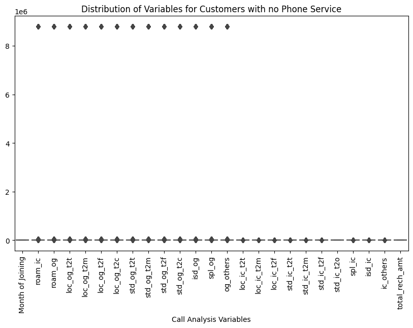

```python
# Plot a boxplot for such values
preserve("fcTel1")
plt.figure(figsize=(10,6))
sns.boxplot(df_call_usage[(df_call_usage['Phone Service']=='No')&(df_call_usage['total_rech_amt'].isin([989,10]))])
plt.title("Distribution of Variables for Customers with no Phone Service")
plt.xlabel("Call Analysis Variables")
plt.xticks(rotation=90)
plt.show()
```

Take note that almost all of the columns have a value close to 0 or 8*E6.

Let's look at the quantiles for all of the outgoing call utilisation columns.

```python
# Specifying the calling columns
outgoing_call_col=['roam_og', 'loc_og_t2t','loc_og_t2m', 'loc_og_t2f', 'loc_og_t2c', 'std_og_t2t', 'std_og_t2m',
                    'std_og_t2f', 'std_og_t2c', 'isd_og', 'spl_og', 'og_others']
```

```python
# Call Usage for customers with no phone service and high recharge amount
df_call_usage[(df_call_usage['Phone Service']=='No')&(df_call_usage['total_rech_amt'].isin([989,10]))][outgoing_call_col].apply(lambda col: col.unique())
```

|  | roam_og | loc_og_t2t | loc_og_t2m | loc_og_t2f | loc_og_t2c | std_og_t2t | std_og_t2m | std_og_t2f | std_og_t2c | isd_og | spl_og | og_others |
| --- | --- | --- | --- | --- | --- | --- | --- | --- | --- | --- | --- | --- |
| 0 | 0.0 | 0.0 | 45.0 | 0.0 | 0.0 | 0.0 | 0.0 | 0.0 | 45.0 | 0.0 | 0.0 | 0.0 |
| 1 | 45.0 | 46254.0 | 0.0 | 46254.0 | 45.0 | 46254.0 | 45.0 | 46254.0 | 0.0 | 45.0 | 45.0 | 45.0 |
| 2 | 46254.0 | 45.0 | 68.0 | 45.0 | 68.0 | 68.0 | 46254.0 | 68.0 | 46254.0 | 46254.0 | 46254.0 | 46254.0 |
| 3 | 8787978.0 | 8787978.0 | 8787978.0 | 8787978.0 | 8787978.0 | 45.0 | 68.0 | 45.0 | 8787978.0 | 68.0 | 8787978.0 | 8787978.0 |
| 4 | 68.0 | 68.0 | 46254.0 | 68.0 | 46254.0 | 8787978.0 | 8787978.0 | 8787978.0 | 68.0 | 8787978.0 | 68.0 | 68.0 |

**Observations**:

- It is noticeable that the values are restricted to a few options including 0, 45, 46254, 8787978, and 68.
- These values seem to have some relation with the recharge amount. However, it is evident that these values are unlikely to be actual data and are likely due to data entry errors.
- In a real-life scenario, it would be advisable to investigate these values with the business to ensure accuracy.
- However, for the purpose of this analysis, we can assume that these values are erroneous and proceed to replace all corresponding recharge amounts with 0.

Before we replace the values, let's see if this recharge amount exists when Phone Service is selected.

```python
# Filter the values where phone service is yes and recharge amt is in 10 or 989
df_call_usage[(df_call_usage['Phone Service']=='Yes')&(df_call_usage['total_rech_amt'].isin([10,989]))]
```

| Customer ID | Month | Month of Joining | roam_ic | roam_og | loc_og_t2t | loc_og_t2m | loc_og_t2f | loc_og_t2c | std_og_t2t | std_og_t2m | std_og_t2f | std_og_t2c | isd_og | spl_og | og_others | loc_ic_t2t | loc_ic_t2m | loc_ic_t2f | std_ic_t2t | std_ic_t2m | std_ic_t2f | std_ic_t2o | spl_ic | isd_ic | ic_others | total_rech_amt | Phone Service |
| --- | --- | --- | --- | --- | --- | --- | --- | --- | --- | --- | --- | --- | --- | --- | --- | --- | --- | --- | --- | --- | --- | --- | --- | --- | --- | --- | --- |
| mvawicevzubbt203 | 14 | 9 | 63.95 | 131.92 | 100.35 | 1355.92 | 8.15 | 13.50 | 29.54 | 47.00 | 184.62 | 0.0 | 204.02 | 49.15 | 14.94 | 210.85 | 213.56 | 84.03 | 24.99 | 52.41 | 6.85 | 0.0 | 0.06 | 62.32 | 62.71 | 10.0 | Yes |
| jqlowmgrrbnsf859 | 7 | 3 | 431.10 | 34.91 | 144.73 | 3167.87 | 0.72 | 325.41 | 312.90 | 1082.27 | 132.53 | 0.0 | 10.80 | 17.51 | 15.77 | 1206.69 | 1360.59 | 1263.17 | 89.62 | 120.54 | 470.70 | 0.0 | 0.11 | 27.28 | 61.76 | 10.0 | Yes |
| antivlmeqegyi1478 | 2 | 1 | 1585.09 | 65.91 | 60.84 | 270.26 | 10.16 | 16.62 | 228.12 | 149.87 | 6.51 | 0.0 | 34.19 | 37.61 | 13.05 | 77.09 | 234.24 | 36.31 | 52.21 | 71.87 | 2.57 | 0.0 | 0.10 | 31.09 | 37.37 | 989.0 | Yes |
| prbkyrzfijozx1616 | 8 | 6 | 1071.48 | 61.74 | NaN | 3512.23 | NaN | 12.76 | 211.10 | 171.00 | 177.56 | NaN | 34.40 | NaN | NaN | 116.68 | 258.67 | 21.65 | NaN | 14.84 | 19.52 | 0.0 | 0.20 | NaN | 2.39 | 10.0 | Yes |
| nhefrsuouiapc1633 | 11 | 6 | 2.71 | 3.69 | 234.75 | 71.46 | 2.26 | 0.30 | 252.63 | 94.80 | 4.57 | 0.0 | 21.35 | 30.77 | 25.27 | 195.37 | 302.69 | 1103.31 | 10.42 | 34.85 | 26.11 | 0.0 | 0.10 | 37.44 | 11.20 | 10.0 | Yes |
| ... | ... | ... | ... | ... | ... | ... | ... | ... | ... | ... | ... | ... | ... | ... | ... | ... | ... | ... | ... | ... | ... | ... | ... | ... | ... | ... | ... |
| fnatcpehazawh161796 | 9 | 9 | 80.14 | 156.87 | 293.52 | 412.47 | 12.84 | 16.61 | 233.59 | 138.33 | 7.28 | 0.0 | 22.02 | 49.50 | 8.41 | 168.15 | 167.59 | 49.46 | 101.87 | 1.32 | 19.36 | 0.0 | 0.05 | 73.82 | 51.04 | 989.0 | Yes |
| zcojuhfysudap162360 | 14 | 5 | 44.33 | 16.68 | 44.36 | 4144.96 | 12.21 | 10.81 | 60.61 | 47.62 | NaN | 0.0 | 19.08 | 12.72 | 16.53 | 10.18 | 105.64 | 32.76 | 8.51 | 71.67 | 23.38 | 0.0 | 0.05 | 57.09 | 7.96 | 10.0 | Yes |
| mbpogbzlhgsal162572 | 13 | 10 | 159.38 | 16.79 | 51.13 | 76.03 | 3.89 | 4.66 | 127.76 | 256.89 | 2.36 | 0.0 | 36.19 | 8.37 | 28.19 | NaN | 97.75 | 72.04 | 25.90 | 50.66 | 23.97 | 0.0 | 0.06 | 74.72 | 27.21 | 10.0 | Yes |
| mrdmgqipiuhvf162579 | 13 | 6 | 647.53 | 108.95 | 140.73 | 82.53 | 5.02 | 13.80 | 667.93 | 144.62 | 0.91 | 0.0 | 36.75 | 40.88 | 16.69 | 190.41 | 81.41 | 64.23 | 120.81 | 36.38 | 32.81 | 0.0 | 2.21 | 46.45 | 5.54 | 10.0 | Yes |
| qauaoorftepng162771 | 9 | 6 | 73.20 | 104.51 | 260.77 | 98.41 | 7.78 | 11.37 | 171.15 | 167.13 | 4.30 | 0.0 | 24.64 | 34.99 | 22.16 | 106.52 | 65.26 | 76.26 | 4.25 | 29.04 | 8.15 | 0.0 | 0.10 | 24.40 | 36.47 | 10.0 | Yes |

631 rows × 26 columns

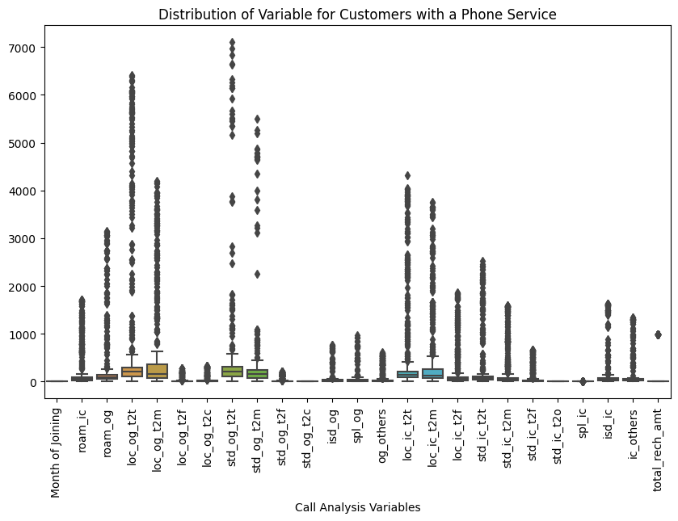

```python
# Plot a boxplot for such values
plt.figure(figsize=(10,6))
sns.boxplot(df_call_usage[(df_call_usage['Phone Service']=='Yes')&(df_call_usage['total_rech_amt'].isin([10,989]))])
plt.title("Distribution of Variable for Customers with a Phone Service")
plt.xlabel("Call Analysis Variables")
plt.xticks(rotation=90)
plt.show()
```

There are no outliers (8*E6) for these values.

This provides us more confidence in replacing the $10, 989 recharge amount when the phone service is not selected.

```python
# Replacing all recharge amounts =0 where there is no phone service
df_call_usage.loc[df_call_usage['Phone Service']=='No','total_rech_amt']=0
```

Now that we've replaced all of the anomalies with 0, let's look at the graph for all of the data again.

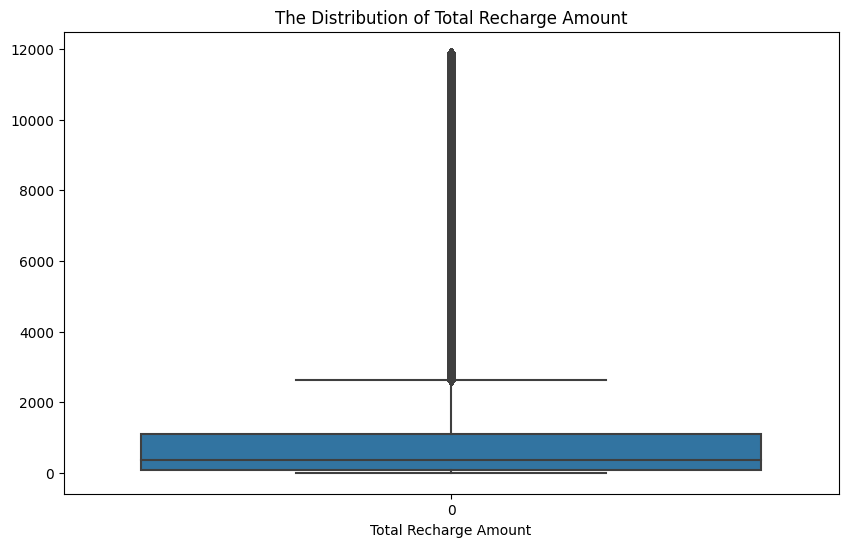

```python
# Plot the the distribution using Box plot
plt.figure(figsize=(10,6))
sns.boxplot(df_call_usage['total_rech_amt'])
plt.title("The Distribution of Total Recharge Amount")
plt.xlabel("Total Recharge Amount")
plt.show()
```

```python
# Shape of the dataframe for recharge amount > 10000
df_call_usage[df_call_usage['total_rech_amt']>10000].shape
```

```
(24984, 26)
```

**Observation**:

- From our previous analysis, we found that more than 25% of customers have a total recharge amount above 1158. Hence, it is not feasible to replace these values. It is possible that these customers have actually made such a high recharge.
- Regarding the customers with a recharge amount of 11875, it is worth checking their usage to verify whether this amount is valid or not.

### **Outgoing Calls Analysis**

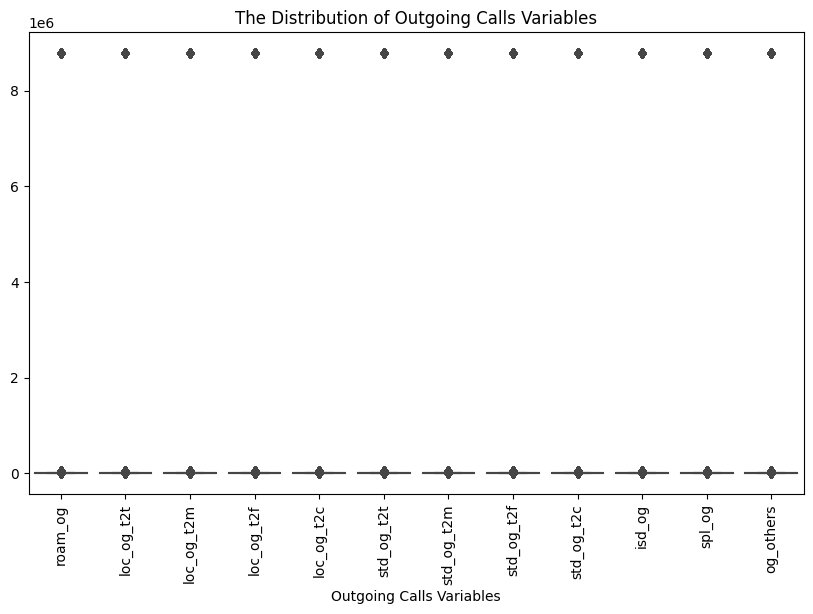

```python
# Plot the the distribution using Box plot
plt.figure(figsize=(10,6))
sns.boxplot(df_call_usage[outgoing_call_col])
plt.title("The Distribution of Outgoing Calls Variables")
plt.xlabel("Outgoing Calls Variables")
plt.xticks(rotation=90)
plt.show()
```

Let us first see the boxplot for consumers who did not select Phone Service.

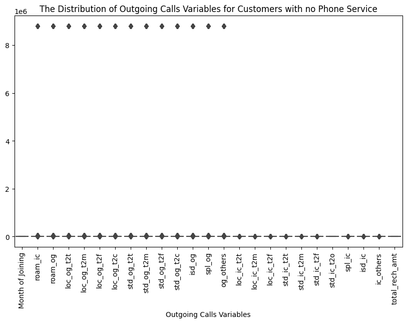

```python
# Plot the the distribution using Box plot
plt.figure(figsize=(10,6))
sns.boxplot(df_call_usage[df_call_usage['Phone Service']=='No'])
plt.title("The Distribution of Outgoing Calls Variables for Customers with no Phone Service")
plt.xlabel("Outgoing Calls Variables")
plt.xticks(rotation=90)
plt.show()
```

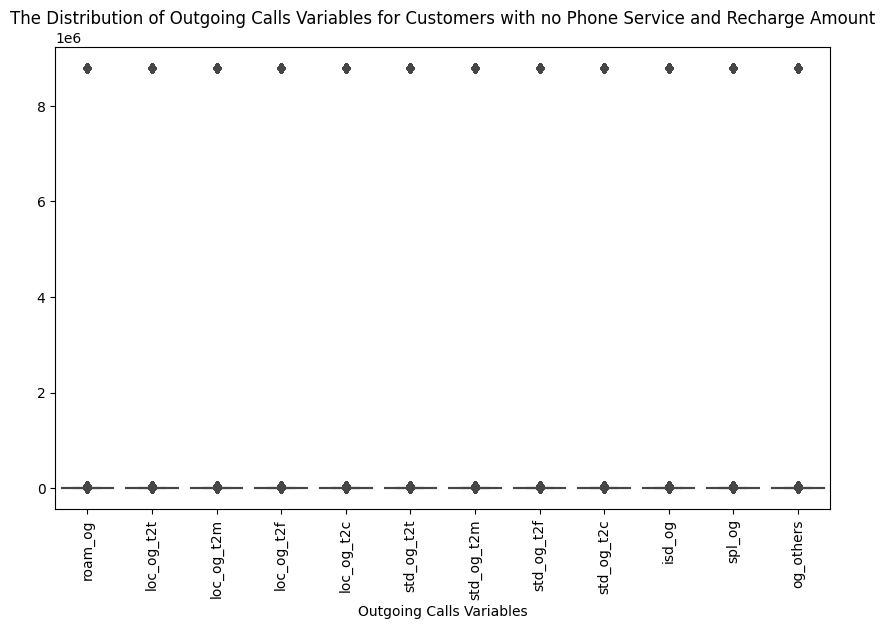

```python
# Plot the the distribution using Box plot
plt.figure(figsize=(10,6))
sns.boxplot(df_call_usage[(df_call_usage['Phone Service']=='No')&(df_call_usage['total_rech_amt']==0)][outgoing_call_col])
plt.title("The Distribution of Outgoing Calls Variables for Customers with no Phone Service and Recharge Amount")
plt.xlabel("Outgoing Calls Variables")
plt.xticks(rotation=90)
plt.show()
```

Customers who did not select Phone Service and whose total recharge amount is 0 have values of 0 or roughly 8*1E6.

Let's look at the boxplot for customers that chose Phone Service.

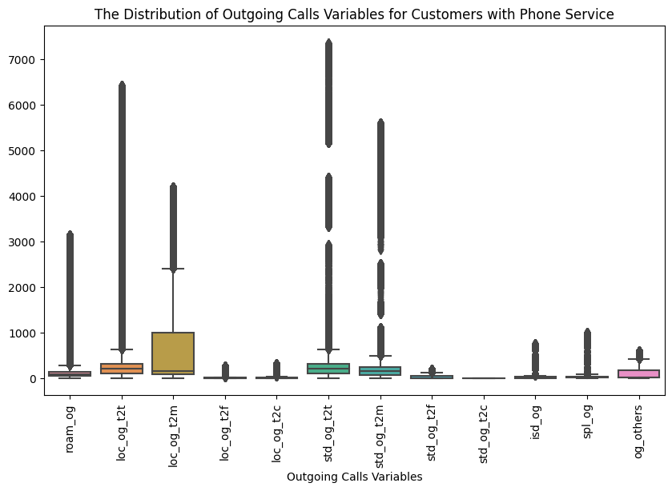

```python
# Plot the the distribution using Box plot
plt.figure(figsize=(10,6))
sns.boxplot(df_call_usage[df_call_usage['Phone Service']=='Yes'][outgoing_call_col])
plt.title("The Distribution of Outgoing Calls Variables for Customers with Phone Service")
plt.xlabel("Outgoing Calls Variables")
plt.xticks(rotation=90)
plt.show()
```

From above two boxplots we can conclude that the abnormal outgoing calls values are only for the customer who didn't opt for Phone Service. Lets analyze those further

```python
# Analyze customers with and without phone service separatelly
df_call_usage_phone_no=df_call_usage[df_call_usage['Phone Service']=='No']
df_call_usage_phone_yes=df_call_usage[df_call_usage['Phone Service']=='Yes']
```

```python
# Columns
df_call_usage_phone_no.columns
```

```
Index(['Month of Joining', 'roam_ic', 'roam_og', 'loc_og_t2t', 'loc_og_t2m',
       'loc_og_t2f', 'loc_og_t2c', 'std_og_t2t', 'std_og_t2m', 'std_og_t2f',
       'std_og_t2c', 'isd_og', 'spl_og', 'og_others', 'loc_ic_t2t',
       'loc_ic_t2m', 'loc_ic_t2f', 'std_ic_t2t', 'std_ic_t2m', 'std_ic_t2f',
       'std_ic_t2o', 'spl_ic', 'isd_ic', 'ic_others', 'total_rech_amt',
       'Phone Service'],
      dtype='object')
```

```python
# Roaming Outgoing Value Counts
df_call_usage_phone_no['roam_og'].value_counts()
```

```
0.0          105884
45.0           7403
46254.0        6263
8787978.0      2564
68.0           2456
Name: roam_og, dtype: int64
```

**Observations**:

- Take note that the figures 8787978 and 46254 are abnormal. It is not possible for a person to make so many outbound calls in a month.
- 46254 minutes is approximately 32 days, which is more than a month.
- As a result, we will replace both values with 0.

```python
# Replacing these values
df_call_usage_phone_no['roam_og']=df_call_usage_phone_no['roam_og'].replace([46254,8787978],0)
```

```python
# Checking the roaming outgoing value counts
df_call_usage_phone_no['roam_og'].value_counts()
```

```
0.0     114711
45.0      7403
68.0      2456
Name: roam_og, dtype: int64
```

```python
# Check where the recharge amount is 0 but we have roaming calls
df_call_usage_phone_no[df_call_usage_phone_no['total_rech_amt']==0]['roam_og'].value_counts()
```

```
0.0     114711
45.0      7403
68.0      2456
Name: roam_og, dtype: int64
```

We took all of the customers that did not opt for phone service, and the recharge amount is 0.

We will replace all of these values with 0 because they cannot make outbound calls without a recharge and a Phone Service plan.

```python
# Replace the values with 0
df_call_usage_phone_no.loc[df_call_usage_phone_no['total_rech_amt']==0,'roam_og']=0
```

```python
# 0 roaming calls for customers with no phone service
df_call_usage_phone_no['roam_og'].value_counts()
```

```
0.0    124570
Name: roam_og, dtype: int64
```

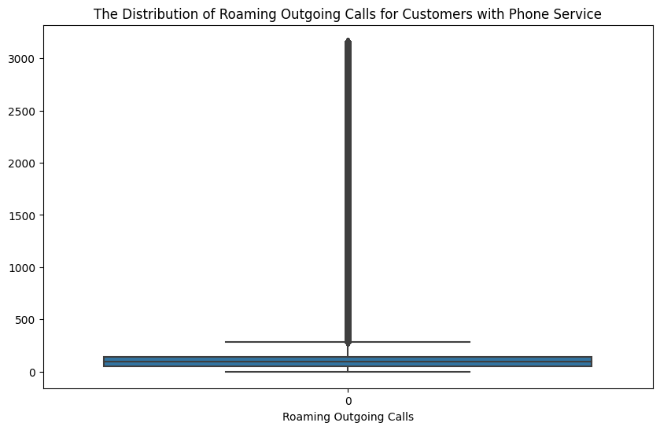

```python
# Plot the the distribution using Box plot
plt.figure(figsize=(10,6))
sns.boxplot(df_call_usage_phone_yes['roam_og'])
plt.title("The Distribution of Roaming Outgoing Calls for Customers with Phone Service")
plt.xlabel("Roaming Outgoing Calls")
plt.show()
```

```python
# Check the quantiles
df_call_usage_phone_yes['roam_og'].quantile([0.1, 0.5,0.75 ,0.9,0.97,0.99])
```

```
0.10      19.24
0.50      94.73
0.75     141.76
0.90    1216.09
0.97    2737.44
0.99    3069.02
Name: roam_og, dtype: float64
```

These values seem to valid. We will now determine the amount of the recharge for these customers.

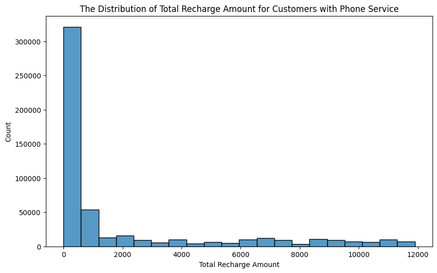

```python
# Plot the the distribution using Box plot
plt.figure(figsize=(10,6))
sns.histplot(data=df_call_usage_phone_yes, x='total_rech_amt', bins=20)
plt.title("The Distribution of Total Recharge Amount for Customers with Phone Service")
plt.xlabel("Total Recharge Amount")
plt.show()
```

```python
# The shape of data where in recharge was 0 for customers with phone service
df_call_usage_phone_yes[df_call_usage_phone_yes['total_rech_amt']==0].shape
```

```
(262, 26)
```

It should be noted that the following customers (262 in total but not all unique) have chosen phone service but there is no recharge amount available.

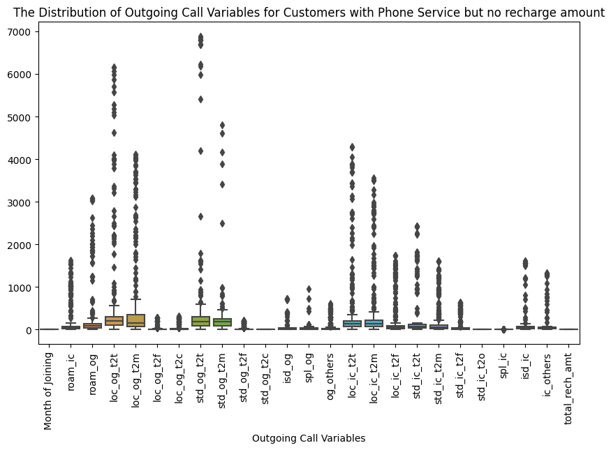

```python
# Plot the the distribution using Box plot
plt.figure(figsize=(10,6))
sns.boxplot(df_call_usage_phone_yes[df_call_usage_phone_yes['total_rech_amt']==0])
plt.title("The Distribution of Outgoing Call Variables for Customers with Phone Service but no recharge amount")
plt.xlabel("Outgoing Call Variables")
plt.xticks(rotation=90)
plt.show()
```

We will not impute any other value for these customer in total_rech_amt. It is possible that company has given them some offer or they might have recharged but its not reflected in the data.

#### **Local outgoing calls within same network in minutes**

```python
# Check the counts
df_call_usage_phone_no['loc_og_t2t'].value_counts()
```

```
0.0          105979
45.0           7430
46254.0        6212
68.0           2511
8787978.0      2438
Name: loc_og_t2t, dtype: int64
```

We will replace the values 46254 and 8787978 in all outgoing call columns.

```python
checkpoint('fcTel1')
for col in outgoing_call_col:
    # for col replace 46254 and 8787978 values with 0
    df_call_usage_phone_no[col]=df_call_usage_phone_no[col].replace([46254,8787978],0)
    # for col replace the value with 0 when there is no phone service and recharge
    df_call_usage_phone_no.loc[df_call_usage_phone_no['total_rech_amt']==0,col]=0
```

```python
# Value counts for all outgoing call variables for customers with no phone service
for col in outgoing_call_col:
    print("value count for ",col)
    print(df_call_usage_phone_no[col].value_counts())
    print("-------------------------")
```

```
value count for  roam_og
0.0    124570
Name: roam_og, dtype: int64
-------------------------
value count for  loc_og_t2t
0.0    124570
Name: loc_og_t2t, dtype: int64
-------------------------
value count for  loc_og_t2m
0.0    124570
Name: loc_og_t2m, dtype: int64
-------------------------
value count for  loc_og_t2f
0.0    124570
Name: loc_og_t2f, dtype: int64
-------------------------
value count for  loc_og_t2c
0.0    124570
Name: loc_og_t2c, dtype: int64
-------------------------
value count for  std_og_t2t
0.0    124570
Name: std_og_t2t, dtype: int64
-------------------------
value count for  std_og_t2m
0.0    124570
Name: std_og_t2m, dtype: int64
-------------------------
value count for  std_og_t2f
0.0    124570
Name: std_og_t2f, dtype: int64
-------------------------
value count for  std_og_t2c
0.0    124570
Name: std_og_t2c, dtype: int64
-------------------------
value count for  isd_og
0.0    124570
Name: isd_og, dtype: int64
-------------------------
value count for  spl_og
0.0    124570
Name: spl_og, dtype: int64
-------------------------
value count for  og_others
0.0    124570
Name: og_others, dtype: int64
-------------------------
```

**Observations**:

- We observed that some customers who did not opt for phone service and have not recharged their account also have not placed any outgoing calls. This makes sense as they are not subscribed to the service and hence cannot make any calls.
- To further analyze the outgoing call patterns, we will focus on customers who have opted for phone service.

```python
# Creating quantile df for outgoing calls
quantile_outgoing_call_df=pd.DataFrame(columns=outgoing_call_col,index=[0.1,0.25,0.5,0.75,0.8,0.9,0.95,0.97,0.99])
```

```python
# Entering data in quantile df
for col in outgoing_call_col:
   quantile_outgoing_call_df[col]=df_call_usage_phone_yes[col].quantile([0.1,0.25,0.5,0.75,0.8,0.9,0.95,0.97,0.99])
```

### **Outgoing call Quantiles for customers with Phone Service**

```python
# Quantile df
quantile_outgoing_call_df
```

|  | roam_og | loc_og_t2t | loc_og_t2m | loc_og_t2f | loc_og_t2c | std_og_t2t | std_og_t2m | std_og_t2f | std_og_t2c | isd_og | spl_og | og_others |
| --- | --- | --- | --- | --- | --- | --- | --- | --- | --- | --- | --- | --- |
| 0.10 | 19.24 | 42.0600 | 33.9300 | 1.740 | 2.0800 | 42.5200 | 31.810 | 1.56 | 0.0 | 4.1100 | 5.5100 | 4.4600 |
| 0.25 | 47.48 | 105.5500 | 84.1200 | 4.430 | 5.1200 | 106.1200 | 80.110 | 3.94 | 0.0 | 10.3200 | 13.7200 | 11.2600 |
| 0.50 | 94.73 | 212.0250 | 167.9800 | 8.910 | 10.2200 | 212.9100 | 160.710 | 7.85 | 0.0 | 20.7900 | 27.6100 | 22.3300 |
| 0.75 | 141.76 | 318.1100 | 1009.9875 | 13.370 | 15.3000 | 319.2400 | 242.390 | 53.04 | 0.0 | 31.2000 | 41.3500 | 172.4125 |
| 0.80 | 151.35 | 1046.8180 | 1744.8500 | 16.210 | 16.3200 | 340.7800 | 258.780 | 93.00 | 0.0 | 33.2600 | 44.0500 | 272.0000 |
| 0.90 | 1216.09 | 4091.4190 | 2908.6810 | 129.924 | 143.2150 | 909.0200 | 466.750 | 152.53 | 0.0 | 37.4200 | 49.5300 | 420.4600 |
| 0.95 | 2273.31 | 5562.5110 | 3644.7170 | 203.742 | 249.4525 | 4093.2425 | 1024.810 | 180.57 | 0.0 | 229.5090 | 426.2400 | 512.7400 |
| 0.97 | 2737.44 | 5935.0189 | 3862.3005 | 211.430 | 289.9475 | 5674.8075 | 4081.317 | 196.05 | 0.0 | 409.1574 | 583.8564 | 545.2727 |
| 0.99 | 3069.02 | 6246.8572 | 4095.4627 | 265.010 | 315.0825 | 6800.0910 | 5036.520 | 210.38 | 0.0 | 648.9958 | 873.3896 | 586.1700 |

All the values in the outgoing call columns for customers with phone service seem to be appropriate and valid. Therefore, we do not need to make any alterations to these values.

Next, we will update the df_call_usage_phone_no and df_call_usage_phone_yes dataframes to the original dataframe.

```python
# Updating the call usage df
df_call_usage.update(df_call_usage_phone_no)
df_call_usage.update(df_call_usage_phone_yes)
```

### **Incoming Calls Analysis**

```python
# Creating incoming calls variables column list
incoming_call_col=['roam_ic','loc_ic_t2t', 'loc_ic_t2m', 'loc_ic_t2f', 'std_ic_t2t',
       'std_ic_t2m', 'std_ic_t2f', 'std_ic_t2o', 'spl_ic', 'isd_ic',
       'ic_others']
```

It should be noted that even if a customer does not have phone service, he or she may receive an incoming call. So we'll just look at quantiles and boxplots for all of the columns.

```python
# Creating quantile df for incoming calls
quantile_incoming_call_df=pd.DataFrame(columns=incoming_call_col,index=[0.1,0.25,0.5,0.75,0.8,0.9,0.95,0.97,0.99])
```

```python
# Entering incoming calls data into the quantile df
for col in quantile_incoming_call_df:
   quantile_incoming_call_df[col]=df_call_usage[col].quantile([0.1,0.25,0.5,0.75,0.8,0.9,0.95,0.97,0.99])
quantile_incoming_call_df
```

|  | roam_ic | loc_ic_t2t | loc_ic_t2m | loc_ic_t2f | std_ic_t2t | std_ic_t2m | std_ic_t2f | std_ic_t2o | spl_ic | isd_ic | ic_others |
| --- | --- | --- | --- | --- | --- | --- | --- | --- | --- | --- | --- |
| 0.10 | 0.0000 | 32.9400 | 32.4100 | 13.9600 | 15.5000 | 12.5700 | 4.880 | 0.0 | 0.02 | 9.4600 | 7.6200 |
| 0.25 | 12.4900 | 80.9700 | 80.7500 | 34.8900 | 38.7500 | 30.9000 | 12.090 | 0.0 | 0.04 | 23.6400 | 19.1000 |
| 0.50 | 49.2900 | 162.4700 | 161.5200 | 69.4950 | 77.2900 | 62.1100 | 24.260 | 0.0 | 0.08 | 47.0300 | 38.0700 |
| 0.75 | 111.8400 | 1039.4300 | 866.7800 | 408.4100 | 115.5500 | 380.1800 | 165.410 | 0.0 | 0.14 | 70.6100 | 57.1900 |
| 0.80 | 370.9840 | 1678.6600 | 1309.3640 | 594.0660 | 123.2320 | 531.8380 | 245.624 | 0.0 | 0.23 | 75.2500 | 61.0100 |
| 0.90 | 1050.6070 | 3045.0360 | 2374.4260 | 1218.9800 | 1440.7410 | 1048.7200 | 469.930 | 0.0 | 0.65 | 472.9730 | 370.4520 |
| 0.95 | 1448.4700 | 3746.3320 | 3194.9620 | 1473.1490 | 2039.9605 | 1377.9870 | 571.450 | 0.0 | 1.33 | 1451.9695 | 927.0530 |
| 0.97 | 1610.0731 | 3927.2384 | 3480.8416 | 1686.0500 | 2165.8986 | 1482.1500 | 595.120 | 0.0 | 1.78 | 1560.8900 | 1236.0818 |
| 0.99 | 46254.0000 | 4209.6656 | 3683.8072 | 1795.8716 | 2442.3681 | 1573.5608 | 639.670 | 0.0 | 2.20 | 1603.3413 | 1319.1303 |

Except for roam_ic, all other columns appear to have appropriate values. We will not change them.

Let us analyze the roam_is column further.

```python
# Counts of unique values in roam_ic column
df_call_usage['roam_ic'].value_counts()
```

```
0.00          105827
45.00           7591
46254.00        6194
8787978.00      2579
68.00           2454
               ...
1441.39            1
1599.70            1
362.26             1
1126.10            1
1318.75            1
Name: roam_ic, Length: 99578, dtype: int64
```

We can also observe 46254 and 8787978 figures here. Let us substitute 0 for them.

Numbers 45 and 68 are also there, but we will not update them because it is possible that they are true values rather than data entering errors.

```python
# Replacing Outliers with 0
df_call_usage['roam_ic']=df_call_usage['roam_ic'].replace([46254,8787978],0)
```

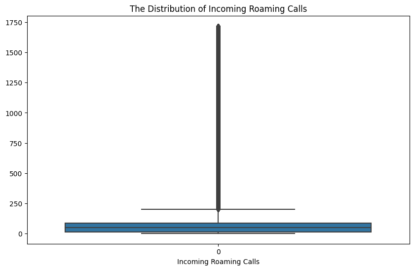

```python
# Plot the the distribution using Box plot
plt.figure(figsize=(10,6))
sns.boxplot(df_call_usage['roam_ic'])
plt.title("The Distribution of Incoming Roaming Calls")
plt.xlabel("Incoming Roaming Calls")
plt.show()
```

### **Internet Services**

```python
# Check customer data usage
df_data_usage=df[['Month of Joining',
        'total_rech_data', 'vol_4g', 'vol_5g',
       'Internet Service']]
```

```python
# Data types involved
df_data_usage.dtypes
```

```
Month of Joining      int64
total_rech_data      object
vol_4g              float64
vol_5g              float64
Internet Service     object
dtype: object
```

Observe that total_rech_data is object but according to data dictionary it should be float.

```python
# Check the value counts
df_data_usage['Internet Service'].value_counts()
```

```
Yes    398863
No     254890
Name: Internet Service, dtype: int64
```

```python
# Total recharge data value counts
df_data_usage['total_rech_data'].value_counts()
```

```
0        216627
2         34246
1         16989
7987      15386
e01       12767
3         10933
8          8172
13         7578
25         7376
4          7119
12         6474
9          5912
7          5647
89890      5086
26         5074
```

[output cut: 23 more lines]

We can see there is e01 value in the column. Let's replace it with 10.

```python
# Replacing the values
df_data_usage['total_rech_data']=df_data_usage['total_rech_data'].replace('e01',10)
```

```python
# Now we will convert the total rech data into a numeric column
df_data_usage['total_rech_data']=pd.to_numeric(df_data_usage['total_rech_data'])
```

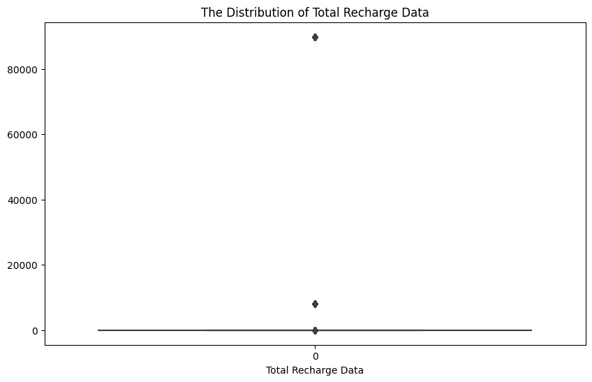

```python
# Plot the the distribution using Box plot
plt.figure(figsize=(10,6))
sns.boxplot(df_data_usage['total_rech_data'])
plt.title("The Distribution of Total Recharge Data")
plt.xlabel("Total Recharge Data")
plt.show()
```

Observe that there are some outliers.

```python
# Check the quantiles
df_data_usage['total_rech_data'].quantile([0.1,0.25,0.5,0.75,0.8,0.9,0.95,0.97,0.99])
```

```
0.10        0.0
0.25        0.0
0.50        1.0
0.75       10.0
0.80       14.0
0.90       25.0
0.95       31.0
0.97     7987.0
0.99    89890.0
Name: total_rech_data, dtype: float64
```

Let's see how many customer have data recharge more than $31.

```python
# Filtering the data
df_data_usage[df_data_usage['total_rech_data']>31]
```

| Customer ID | Month | Month of Joining | total_rech_data | vol_4g | vol_5g | Internet Service |
| --- | --- | --- | --- | --- | --- | --- |
| zcpjiqpcepwze6 | 10 | 9 | 7987.0 | 0.00 | 0.00 | No |
| teequpgyuzwce14 | 3 | 2 | 7987.0 | 0.00 | 0.00 | No |
| pmrwmbcxiuxgx17 | 7 | 7 | 7987.0 | 63.00 | 0.00 | No |
| ucpurmfkdlnwi18 | 14 | 12 | 7987.0 | 0.00 | 0.00 | No |
| pmjtlwcmmdtqy25 | 11 | 2 | 89890.0 | 0.00 | 254687.00 | No |
| ... | ... | ... | ... | ... | ... | ... |
| dxkygyzyqaavm162947 | 7 | 2 | 7987.0 | 0.00 | 0.00 | No |
| bwxzpxwwzyzqu162949 | 7 | 6 | 7987.0 | 0.00 | 0.00 | No |
| raxqiaucxntke162967 | 12 | 9 | 7987.0 | 0.00 | 87978.00 | No |
| lruagtlysjpjy162968 | 10 | 6 | 32.0 | 1340.84 | 15301.67 | Yes |
| uvuizvgyombnd162975 | 12 | 9 | 89890.0 | 0.00 | 0.00 | No |

21985 rows × 5 columns

We can observe that many of them have not chosen Internet Service. Let's look at the unique numbers for total rech data where customers have not chosen Internet Service.

```python
# Check the total recharge data unique value counts where in there is no internet service
df_data_usage[df_data_usage['Internet Service']=='No']['total_rech_data'].value_counts()
```

```
0.0        216627
7987.0      15386
10.0        12767
89890.0      5086
1.6          5024
Name: total_rech_data, dtype: int64
```

The 10 and 1.6 data recharge amounts appear to be correct. We need to analyze further and decide whether to replace the values or remove the No from the Internet service.

89890 and 7987 appear to be absurd values. Because there is no Internet Service Plan, we can replace them with 0.

```python
# Replacing absurd values with 0
df_data_usage['total_rech_data']=df_data_usage['total_rech_data'].replace([7987,89890],0)
```

Let's look at 10 and 1.6 now.

```python
# Checking volumes of 4g and 5g data where internet service is no
df_data_usage[(df_data_usage['Internet Service']=='No')&(df_data_usage['total_rech_data'].isin([10,1.6]))][['vol_4g','vol_5g']].apply(lambda col: col.unique())
```

|  | vol_4g | vol_5g |
| --- | --- | --- |
| 0 | 0.0 | 0.0 |
| 1 | 63.0 | 254687.0 |
| 2 | 254687.0 | 63.0 |
| 3 | 87978.0 | 87978.0 |
| 4 | 789.0 | 789.0 |

```python
# Checking volumes of 4g and 5g data where internet service is yes
df_data_usage[(df_data_usage['Internet Service']=='Yes')&(df_data_usage['total_rech_data'].isin([10,1.6]))][['vol_4g','vol_5g']].apply(lambda col: col.unique())
```

```
vol_4g    [207.01, 147.78, 606.91, 175.48, 183.36, 1.42,...
vol_5g    [3394.04, 9925.61, 3483.1, 9181.66, 236.32, 16...
dtype: object
```

**Observations**:

- We can clearly observe that anytime a data recharge of 10 or 1.6 is made and the Internet service is selected, the vol 4g and vol 5g have varying values.
- But, when the Internet service is turned off, the results are either 0, 63, 254687, 87978, or 789.
- We can go to business and inquire about this here.

```python
# Replacing the values
df_data_usage.loc[df_data_usage['Internet Service']=='No','total_rech_data']=0
```

For customers who did not choose Internet service, we replaced all data with 0.

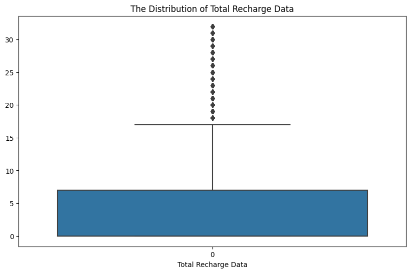

```python
# Plot the the distribution using Box plot
plt.figure(figsize=(10,6))
sns.boxplot(df_data_usage['total_rech_data'])
plt.title("The Distribution of Total Recharge Data")
plt.xlabel("Total Recharge Data")
plt.show()
```

There are some customers who are above the 75th percentile. We are not going to change those values.

We already discussed imputing arpu 4g and arpu 5g after analyzing this variable, so let's do it now.

```python
# Check the value counts for total recharge data where arpu 4g and 5g is null
df[(df['arpu_4g'].isna())&(df['arpu_5g'].isna())]['total_rech_data'].value_counts(dropna=False)
```

```
NaN    195182
13        802
30        744
26        725
27        711
12        656
16        583
29        458
25        386
31        370
19        332
15        317
32        159
18        152
24         97
20         41
Name: total_rech_data, dtype: int64
```

```python
# Replacing the values with Not Applicable
df.loc[(df['arpu_4g'].isna())&(df['arpu_5g'].isna())&(df['total_rech_data'].isna()),['arpu_4g','arpu_5g']]='Not Applicable'
```

### **vol_4g and vol_5g columns**

```python
# separately analyzing the internet volumes for customers with and without inetrnet service
df_data_usage_internet_no=df_data_usage[df_data_usage['Internet Service']=='No']
df_data_usage_internet_yes=df_data_usage[df_data_usage['Internet Service']=='Yes']
```

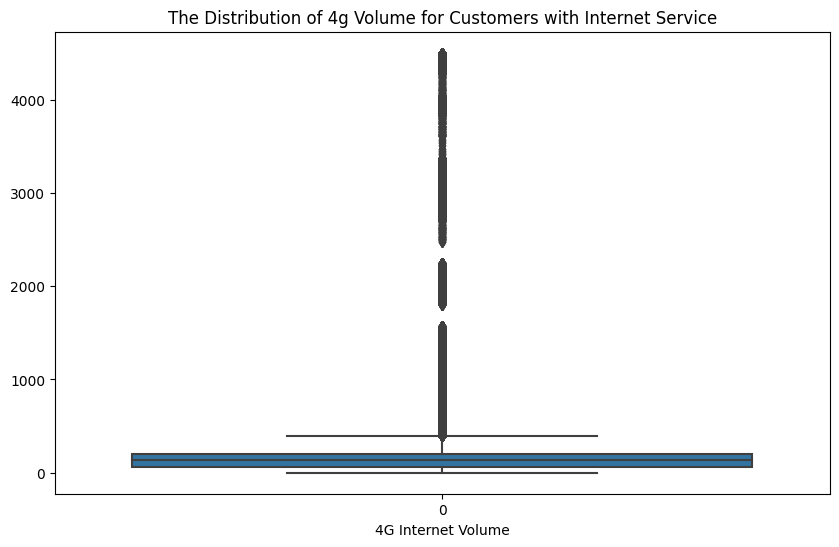

```python
# Plot the the distribution using Box plot
plt.figure(figsize=(10,6))
sns.boxplot(df_data_usage_internet_yes['vol_4g'])
plt.title("The Distribution of 4g Volume for Customers with Internet Service")
plt.xlabel("4G Internet Volume")
plt.show()
```

```python
# Check the quantiles
df_data_usage_internet_yes['vol_4g'].quantile([0.1,0.25,0.5,0.75,0.8,0.9,0.95,0.97,0.99])
```

```
0.10      25.9600
0.25      65.6100
0.50     131.6000
0.75     196.6000
0.80     209.9400
0.90     505.9800
0.95    1407.9740
0.97    2888.7584
0.99    4370.9476
Name: vol_4g, dtype: float64
```

We will not alter any of these values.

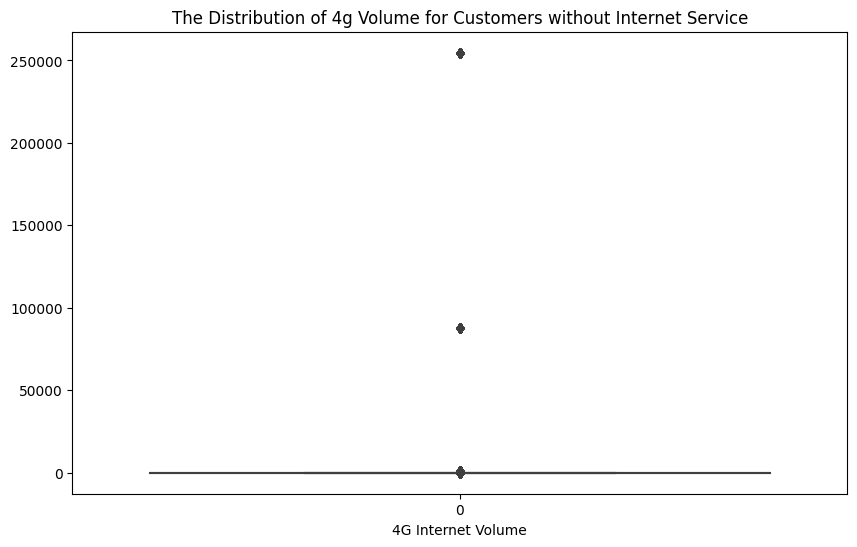

```python
# Plot the the distribution using Box plot
plt.figure(figsize=(10,6))
sns.boxplot(df_data_usage_internet_no['vol_4g'])
plt.title("The Distribution of 4g Volume for Customers without Internet Service")
plt.xlabel("4G Internet Volume")
plt.show()
```

The abnormal values are when Internet service is not opted.

```python
# Value counts of 4g data without inetrnet service
df_data_usage_internet_no['vol_4g'].value_counts()
```

```
0.0         216587
63.0         15419
254687.0     12656
789.0         5152
87978.0       5076
Name: vol_4g, dtype: int64
```

Let's see how many of these values are there without any data recharge.

```python
# Count the values in 4G volume with no internet service and recharge data
df_data_usage_internet_no[df_data_usage_internet_no['total_rech_data']==0]['vol_4g'].value_counts()
```

```
0.0         216587
63.0         15419
254687.0     12656
789.0         5152
87978.0       5076
Name: vol_4g, dtype: int64
```

When vol-4g data is utilised in GB, the values 254687 and 87978 appear to be absurd. Let us substitute 0 for them.

We earlier saw that the customers had recharged with 10, 1.6, or other absurd quantities, and we replaced all data recharge amounts with 0.

Similarly, we will replace all of the values here.

```python
# Replacing the value with 0
df_data_usage_internet_no.loc[df_data_usage_internet_no['total_rech_data']==0,'vol_4g']=0
```

```python
# Checking the values of 4g volume without internet service
df_data_usage_internet_no['vol_4g'].value_counts()
```

```
0.0    254890
Name: vol_4g, dtype: int64
```

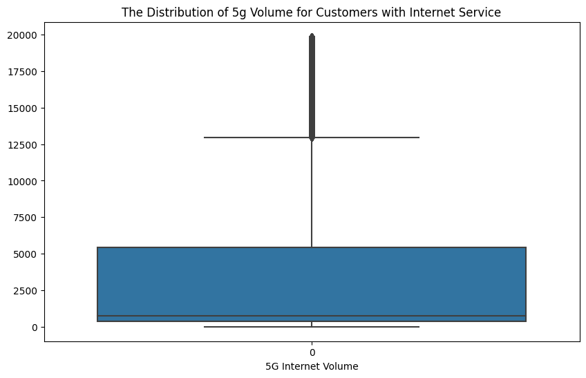

```python
# Plot the the distribution using Box plot
plt.figure(figsize=(10,6))
sns.boxplot(df_data_usage_internet_yes['vol_5g'])
plt.title("The Distribution of 5g Volume for Customers with Internet Service")
plt.xlabel("5G Internet Volume")
plt.show()
```

```python
# Check the quantiles
df_data_usage_internet_yes['vol_5g'].quantile([0.1,0.25,0.5,0.75,0.8,0.9,0.95,0.97,0.99])
```

```
0.10      152.3420
0.25      379.8600
0.50      759.6000
0.75     5410.0500
0.80     8277.9360
0.90    13588.3860
0.95    16489.9130
0.97    17684.4026
0.99    19090.8604
Name: vol_5g, dtype: float64
```

```python
# Check the 5g volume value counts for customers with no internet service
df_data_usage_internet_no['vol_5g'].value_counts()
```

```
0.0         216464
63.0         15314
254687.0     12889
87978.0       5183
789.0         5040
Name: vol_5g, dtype: int64
```

The abnormal values are there when Internet service is not opted.

```python
# Value counts of 5g volume without internet service
df_data_usage_internet_no[df_data_usage_internet_no['total_rech_data']==0]['vol_5g'].value_counts()
```

```
0.0         216464
63.0         15314
254687.0     12889
87978.0       5183
789.0         5040
Name: vol_5g, dtype: int64
```

**Observations**:

- It is worth noting that all customers with large amounts of data consumption have either recharged with 0, 10, or 1.6, which appears to be unusual. We will now replace all of these values.
- Because vol-5g is data utilised in GB, the values 254687 and 87978 appear to be absurd. Let us substitute 0 for them.

```python
# Replacing values with 0
df_data_usage_internet_no.loc[df_data_usage_internet_no['total_rech_data']==0,'vol_5g']=0
```

```python
# Check the counts again
df_data_usage_internet_no['vol_5g'].value_counts()
```

```
0.0    254890
Name: vol_5g, dtype: int64
```

```python
# update the dataframes
df_data_usage.update(df_data_usage_internet_no)
df_data_usage.update(df_data_usage_internet_yes)
```

We have updated all of the df data usage and df call usage values.

We can update both of them in our main dataframe df.

```python
# Update original dataframe
df.update(df_call_usage)
df.update(df_data_usage)
```

Let's now check % of missing values in the data!

```python
# Creating a missing value df with the null values of our original dataframe
percent_missing = df.isna().sum() * 100 / len(df)
missing_value_df = pd.DataFrame({'column_name': df.columns,
                                 'percent_missing': percent_missing.values})
```

```python
# Percentage of missing values in each column
missing_value_df
```

|  | column_name | percent_missing |
| --- | --- | --- |
| 0 | Month of Joining | 0.000000 |
| 1 | zip_code | 0.000000 |
| 2 | Gender | 0.000000 |
| 3 | Age | 1.562364 |
| 4 | Married | 0.000000 |
| 5 | Dependents | 0.000000 |
| 6 | Number of Dependents | 0.756402 |
| 7 | Location ID | 0.000000 |
| 8 | Service ID | 0.000000 |
| 9 | state | 0.000000 |
| 10 | county | 0.000000 |
| 11 | timezone | 0.000000 |
| 12 | area_codes | 0.000000 |
| 13 | country | 0.000000 |
| 14 | latitude | 0.000000 |
| 15 | longitude | 0.000000 |
| 16 | arpu | 0.000000 |
| 17 | roam_ic | 4.409769 |
| 18 | roam_og | 3.102395 |
| 19 | loc_og_t2t | 4.235698 |
| 20 | loc_og_t2m | 4.284340 |
| 21 | loc_og_t2f | 10.289207 |
| 22 | loc_og_t2c | 3.549812 |
| 23 | std_og_t2t | 5.692823 |
| 24 | std_og_t2m | 7.040427 |
| 25 | std_og_t2f | 4.194245 |
| 26 | std_og_t2c | 16.976595 |
| 27 | isd_og | 6.354082 |
| 28 | spl_og | 14.387085 |
| 29 | og_others | 3.287327 |
| 30 | loc_ic_t2t | 5.365941 |
| 31 | loc_ic_t2m | 4.105220 |
| 32 | loc_ic_t2f | 3.645261 |
| 33 | std_ic_t2t | 8.769826 |
| 34 | std_ic_t2m | 4.008548 |
| 35 | std_ic_t2f | 2.841899 |
| 36 | std_ic_t2o | 12.785869 |
| 37 | spl_ic | 5.090149 |
| 38 | isd_ic | 12.659980 |
| 39 | ic_others | 6.203413 |
| 40 | total_rech_amt | 0.000000 |
| 41 | total_rech_data | 32.107539 |
| 42 | vol_4g | 0.000000 |
| 43 | vol_5g | 0.000000 |
| 44 | arpu_5g | 2.397389 |
| 45 | arpu_4g | 2.621326 |
| 46 | night_pck_user | 57.070943 |
| 47 | fb_user | 62.775085 |
| 48 | aug_vbc_5g | 2.714634 |
| 49 | Churn Value | 0.000000 |
| 50 | Referred a Friend | 0.000000 |
| 51 | Number of Referrals | 0.059197 |
| 52 | Phone Service | 0.000000 |
| 53 | Multiple Lines | 0.000000 |
| 54 | Internet Service | 0.000000 |
| 55 | Internet Type | 33.243748 |
| 56 | Streaming Data Consumption | 0.000000 |
| 57 | Online Security | 0.000000 |
| 58 | Online Backup | 0.000000 |
| 59 | Device Protection Plan | 0.000000 |
| 60 | Premium Tech Support | 0.000000 |
| 61 | Streaming TV | 0.000000 |
| 62 | Streaming Movies | 0.000000 |
| 63 | Streaming Music | 0.000000 |
| 64 | Unlimited Data | 0.000000 |
| 65 | Payment Method | 0.000000 |
| 66 | Status ID | 0.000000 |
| 67 | Satisfaction Score | 0.000000 |
| 68 | Churn Category | 0.000000 |
| 69 | Churn Reason | 0.000000 |
| 70 | Customer Status | 0.000000 |
| 71 | offer | 0.000000 |

```python
# Missing value columns with > 20 % missing values
missing_value_df[missing_value_df.percent_missing>20]
```

|  | column_name | percent_missing |
| --- | --- | --- |
| 41 | total_rech_data | 32.107539 |
| 46 | night_pck_user | 57.070943 |
| 47 | fb_user | 62.775085 |
| 55 | Internet Type | 33.243748 |

Missing values greater than 20% should not be imputed because the imputation process may introduce bias and distort the true distribution of the data. Imputing a large percentage of missing values may also result in unreliable and inaccurate analysis. In such cases, it may be better to drop the columns!

Let's select all the columns with less missing values and impute them.

```python
# We will only select columns with <20% missing values
missing_impute_cols=list(missing_value_df[(missing_value_df.percent_missing>1)&(missing_value_df.percent_missing<20)]['column_name'])
```

```python
# All columns with missing values less than 20 %
missing_impute_cols
```

```
['Age',
 'roam_ic',
 'roam_og',
 'loc_og_t2t',
 'loc_og_t2m',
 'loc_og_t2f',
 'loc_og_t2c',
 'std_og_t2t',
 'std_og_t2m',
 'std_og_t2f',
 'std_og_t2c',
 'isd_og',
 'spl_og',
 'og_others',
 'loc_ic_t2t',
 'loc_ic_t2m',
 'loc_ic_t2f',
 'std_ic_t2t',
 'std_ic_t2m',
 'std_ic_t2f',
 'std_ic_t2o',
 'spl_ic',
 'isd_ic',
 'ic_others',
 'arpu_5g',
 'arpu_4g',
 'aug_vbc_5g']
```

```python
# Shape
df[missing_impute_cols].shape
```

```
(653753, 27)
```

## **Imputation Techniques**

Data imputation refers to the process of filling in missing values in a dataset. In machine learning, imputing missing values is important because many algorithms are sensitive to missing values and cannot handle them effectively. If missing values are not handled, they can lead to biased or incorrect results, especially when using methods like regression, decision trees, and clustering.

There are several techniques used for data imputation in machine learning, including:

Mean/Median/Mode imputation: In this method, missing values are replaced by the mean, median, or mode of the non-missing values in the same column. Mean imputation is used for continuous variables, median imputation for ordinal variables, and mode imputation for categorical variables. This method is simple and easy to implement, but it can result in loss of information and introduce bias if the distribution of the data is not symmetrical.

Regression imputation: In this method, a regression model is used to predict the missing values based on the values of the other variables in the dataset. The regression model can be linear, polynomial, or any other type of regression model. The advantage of this method is that it can capture the relationship between the variables, but it requires a well-defined regression model and can result in overfitting if the model is too complex.

## **Multivariate Imputation by Chained Equation (MICE)**

MICE algorithm is probably one of the most used imputation techniques and also a popular interview question.

Multivariate Imputation by Chained Equation (MICE) is a statistical technique used to impute missing values in a dataset with multiple variables. MICE is a flexible and powerful imputation method that can handle missing data in both continuous and categorical variables, as well as variables with complex relationships.

MICE works by creating multiple imputed datasets, where missing values are imputed based on the observed values of other variables in the dataset. The imputation process is performed in a sequential manner, where each variable is imputed conditional on the observed values of the other variables in the dataset. This process is repeated multiple times, with each iteration generating a new set of imputed values for the missing data.

The mathematical formulation of MICE can be described as follows:

Suppose we have a dataset $Y$ with n observations and p variables, where some of the values are missing. Let $\hat{Y}$ denote the imputed dataset, where missing values are replaced by imputed values.

The MICE algorithm can be broken down into the following steps:

- Initialization: Initialize the imputed dataset $\hat{Y}$ by using a simple imputation method, such as mean imputation or regression imputation.
- To apply MICE algorithm, we will use IterativeImputer from scikit-learn. This estimator is still under experimental so we must import enable_iterative_imputer.
- Iteration: For each variable i, impute the missing values using the conditional distribution of i given the observed values of the other variables in $\hat{Y}$. Let $\hat{Y_i}$ denote the imputed values for variable i, where missing values are replaced by imputed values. Repeat this step for all variables in the dataset.
- Convergence: Repeat the iteration step multiple times until the imputed values converge to a stable solution. This can be assessed by examining the convergence of the imputed values across iterations.
- Combining: After multiple imputed datasets have been created, combine the results using a formula that takes into account the uncertainty in the imputed values. For example, the final imputed value for a variable could be the average of the imputed values across multiple datasets.

The MICE algorithm can be expressed mathematically using the following formula: \begin{equation} Y_{i}^{*} = f_{i}(Y_{1}, Y_{2}, ..., Y_{i-1}, Y_{i+1}, ..., Y_{p}) \end{equation} where $Y_{i}^{*}$ is the imputed value for variable i, $f_{i}$ is the imputation model for variable i, and $Y_{1}$, $Y_{2}$, ..., $Y_{i-1}$, $Y_{i+1}$, ..., $Y_{p}$ are the observed values of the other variables in the dataset.

MICE is a powerful imputation method that can handle missing data in complex datasets. It has been shown to be more accurate than other imputation methods, such as listwise deletion and mean imputation.

```python
# Imputing with MICE
from sklearn.experimental import enable_iterative_imputer
from sklearn.impute import IterativeImputer
from sklearn import linear_model
```

```python
# Columns with Missing Values
missing_impute_cols
```

```
['Age',
 'roam_ic',
 'roam_og',
 'loc_og_t2t',
 'loc_og_t2m',
 'loc_og_t2f',
 'loc_og_t2c',
 'std_og_t2t',
 'std_og_t2m',
 'std_og_t2f',
 'std_og_t2c',
 'isd_og',
 'spl_og',
 'og_others',
 'loc_ic_t2t',
 'loc_ic_t2m',
 'loc_ic_t2f',
 'std_ic_t2t',
 'std_ic_t2m',
 'std_ic_t2f',
 'std_ic_t2o',
 'spl_ic',
 'isd_ic',
 'ic_others',
 'arpu_5g',
 'arpu_4g',
 'aug_vbc_5g']
```

```python
# Filtering and creating a copy dataframe
df_mice = df.filter(missing_impute_cols, axis=1).copy()
```

```python
# Top three rows
df_mice.head(3)
```

| Customer ID | Month | Age | roam_ic | roam_og | loc_og_t2t | loc_og_t2m | loc_og_t2f | loc_og_t2c | std_og_t2t | std_og_t2m | std_og_t2f | std_og_t2c | isd_og | spl_og | og_others | loc_ic_t2t | loc_ic_t2m | loc_ic_t2f | std_ic_t2t | std_ic_t2m | std_ic_t2f | std_ic_t2o | spl_ic | isd_ic | ic_others | arpu_5g | arpu_4g | aug_vbc_5g |
| --- | --- | --- | --- | --- | --- | --- | --- | --- | --- | --- | --- | --- | --- | --- | --- | --- | --- | --- | --- | --- | --- | --- | --- | --- | --- | --- | --- | --- |
| hthjctifkiudi0 | 1 | 36.0 | 18.88 | 78.59 | 280.32 | 30.97 | 5.71 | 1.79 | 25.71 | 175.56 | 0.47 | 0.0 | 5.11 | 0.65 | 13.99 | 121.51 | 168.40 | 67.61 | 115.69 | 52.22 | 18.71 | 0.0 | 0.26 | 11.53 | 46.42 | Not Applicable | Not Applicable | 214.99 |
| uqdtniwvxqzeu1 | 6 | NaN | 69.46 | 72.08 | 255.73 | 148.80 | 30.00 | 7.61 | 308.29 | 265.20 | 10.82 | 0.0 | 1.23 | 905.51 | 1.69 | 212.93 | 155.19 | 29.04 | 9.15 | 38.89 | 0.84 | 0.0 | 0.05 | 32.51 | 25.53 | 0.0 | 0.0 | 0.00 |
|  | 7 | NaN | 1012.60 | 115.26 | 52.95 | NaN | 103.28 | 15.71 | 244.20 | 15.19 | NaN | NaN | 13.14 | 455.15 | 115.63 | 121.80 | 699.39 | 44.49 | 83.59 | 914.70 | 13.25 | 0.0 | 0.06 | 13.05 | 5.62 | -9.4 | 106.3 | 85.87 |

```python
# Data types involved
df_mice.dtypes
```

```
Age           float64
roam_ic       float64
roam_og       float64
loc_og_t2t    float64
loc_og_t2m    float64
loc_og_t2f    float64
loc_og_t2c    float64
std_og_t2t    float64
std_og_t2m    float64
std_og_t2f    float64
std_og_t2c    float64
isd_og        float64
spl_og        float64
og_others     float64
loc_ic_t2t    float64
loc_ic_t2m    float64
loc_ic_t2f    float64
std_ic_t2t    float64
std_ic_t2m    float64
std_ic_t2f    float64
std_ic_t2o    float64
spl_ic        float64
isd_ic        float64
ic_others     float64
arpu_5g        object
arpu_4g        object
aug_vbc_5g    float64
dtype: object
```

```python
# Not imputing missing values now
missing_impute_cols.remove('arpu_4g')
missing_impute_cols.remove('arpu_5g')
```

```python
# Creating the copy dataframe for mice imputation
df_mice = df.filter(missing_impute_cols, axis=1).copy()
```

```python
# Define MICE Imputer and fill missing values
mice_imputer = IterativeImputer(estimator=linear_model.BayesianRidge(), n_nearest_features=None, imputation_order='ascending')
```

```python
# Fit Transform the data
df_mice_imputed = pd.DataFrame(mice_imputer.fit_transform(df_mice), columns=df_mice.columns,index=df_mice.index)
save_point("fcTel1")
```

```python
# Top three rows after imputation
df_mice_imputed.head(3)
```

| Customer ID | Month | Age | roam_ic | roam_og | loc_og_t2t | loc_og_t2m | loc_og_t2f | loc_og_t2c | std_og_t2t | std_og_t2m | std_og_t2f | std_og_t2c | isd_og | spl_og | og_others | loc_ic_t2t | loc_ic_t2m | loc_ic_t2f | std_ic_t2t | std_ic_t2m | std_ic_t2f | std_ic_t2o | spl_ic | isd_ic | ic_others | aug_vbc_5g |
| --- | --- | --- | --- | --- | --- | --- | --- | --- | --- | --- | --- | --- | --- | --- | --- | --- | --- | --- | --- | --- | --- | --- | --- | --- | --- | --- |
| hthjctifkiudi0 | 1 | 36.000000 | 18.88 | 78.59 | 280.32 | 30.970000 | 5.71 | 1.79 | 25.71 | 175.56 | 0.470000 | 0.0 | 5.11 | 0.65 | 13.99 | 121.51 | 168.40 | 67.61 | 115.69 | 52.22 | 18.71 | 0.0 | 0.26 | 11.53 | 46.42 | 214.99 |
| uqdtniwvxqzeu1 | 6 | 36.657198 | 69.46 | 72.08 | 255.73 | 148.800000 | 30.00 | 7.61 | 308.29 | 265.20 | 10.820000 | 0.0 | 1.23 | 905.51 | 1.69 | 212.93 | 155.19 | 29.04 | 9.15 | 38.89 | 0.84 | 0.0 | 0.05 | 32.51 | 25.53 | 0.00 |
|  | 7 | 36.607828 | 1012.60 | 115.26 | 52.95 | 1151.693063 | 103.28 | 15.71 | 244.20 | 15.19 | 61.837211 | 0.0 | 13.14 | 455.15 | 115.63 | 121.80 | 699.39 | 44.49 | 83.59 | 914.70 | 13.25 | 0.0 | 0.06 | 13.05 | 5.62 | 85.87 |

```python
# Verifying the imputation
df_mice_imputed.isna().sum()
```

```
Age           0
roam_ic       0
roam_og       0
loc_og_t2t    0
loc_og_t2m    0
loc_og_t2f    0
loc_og_t2c    0
std_og_t2t    0
std_og_t2m    0
std_og_t2f    0
std_og_t2c    0
isd_og        0
spl_og        0
og_others     0
loc_ic_t2t    0
loc_ic_t2m    0
loc_ic_t2f    0
std_ic_t2t    0
std_ic_t2m    0
std_ic_t2f    0
std_ic_t2o    0
spl_ic        0
isd_ic        0
ic_others     0
aug_vbc_5g    0
dtype: int64
```

Let's update this dataframe to original dataframe!

```python
# Update the original dataframe
df.update(df_mice_imputed)
```

```python
# Top three rows
df.head(3)
```

| Customer ID | Month | Month of Joining | zip_code | Gender | Age | Married | Dependents | Number of Dependents | Location ID | Service ID | state | county | timezone | area_codes | country | latitude | longitude | arpu | roam_ic | roam_og | loc_og_t2t | loc_og_t2m | loc_og_t2f | loc_og_t2c | std_og_t2t | std_og_t2m | std_og_t2f | std_og_t2c | isd_og | … |
| --- | --- | --- | --- | --- | --- | --- | --- | --- | --- | --- | --- | --- | --- | --- | --- | --- | --- | --- | --- | --- | --- | --- | --- | --- | --- | --- | --- | --- | --- | --- |
| hthjctifkiudi0 | 1 | 1.0 | 71638 | Female | 36.000000 | No | No | 0.0 | jeavwsrtakgq0 | bfbrnsqreveeuafgps0 | AR | Chicot County | America/Chicago | 870.0 | US | 33.52 | -91.43 | 273.07 | 18.88 | 78.59 | 280.32 | 30.970000 | 5.71 | 1.79 | 25.71 | 175.56 | 0.470000 | 0.0 | 5.11 | … |
| uqdtniwvxqzeu1 | 6 | 6.0 | 72566 | Male | 36.657198 | No | No | 0.0 | qcvetdmalnkw1 | tkqnsqflrdatnqapsh1 | AR | Izard County | America/Chicago | 870.0 | US | 36.22 | -92.08 | -329.96 | 69.46 | 72.08 | 255.73 | 148.800000 | 30.00 | 7.61 | 308.29 | 265.20 | 10.820000 | 0.0 | 1.23 | … |
|  | 7 | 6.0 | 72566 | Male | 36.607828 | No | No | 0.0 | qcvetdmalnkw1 | tkqnsqflrdatnqapsh1 | AR | Izard County | America/Chicago | 870.0 | US | 36.22 | -92.08 | 101.22 | 1012.60 | 115.26 | 52.95 | 1151.693063 | 103.28 | 15.71 | 244.20 | 15.19 | 61.837211 | 0.0 | 13.14 | … |

Let's do imputation for arpu_4g and arpu_5g!

```python
# Select the columns
df_arpu=df[['arpu_4g','arpu_5g']]
```

```python
# Filtering the 4G ARPU dataframe where values are not "Not Applicable"
df_arpu_filterd=df_arpu[df_arpu.arpu_4g!='Not Applicable']
```

```python
# # Filtering the 5g ARPU dataframe where values are not "Not Applicable"
df_arpu_filterd=df_arpu_filterd[df_arpu_filterd.arpu_5g!='Not Applicable']
```

```python
# Top three rows
df_arpu_filterd.head(3)
```

| Customer ID | Month | arpu_4g | arpu_5g |
| --- | --- | --- | --- |
| uqdtniwvxqzeu1 | 6 | 0.0 | 0.0 |
|  | 7 | 106.3 | -9.4 |
|  | 8 | 77.53 | -5.15 |

```python
# Fit transform rest of the data for 4G and 5G ARPU
df_arpu_mice_imputed = pd.DataFrame(mice_imputer.fit_transform(df_arpu_filterd), columns=df_arpu_filterd.columns,index=df_arpu_filterd.index)
```

```python
# Top three rows for imputed data
df_arpu_mice_imputed.head(3)
```

| Customer ID | Month | arpu_4g | arpu_5g |
| --- | --- | --- | --- |
| uqdtniwvxqzeu1 | 6 | 0.00 | 0.00 |
|  | 7 | 106.30 | -9.40 |
|  | 8 | 77.53 | -5.15 |

Let's update this to original dataframe!

```python
# Verifying that there are no missing values
df_arpu_mice_imputed.isna().sum()
```

```
arpu_4g    0
arpu_5g    0
dtype: int64
```

```python
# Updating the main dataframe
df.update(df_arpu_mice_imputed)
```

```python
# Verifying that there are no missing values
df[df['arpu_4g'].isna()]
```

|  |  | Month of Joining | zip_code | Gender | Age | Married | Dependents | Number of Dependents | Location ID | Service ID | state | county | timezone | area_codes | country | latitude | longitude | arpu | roam_ic | roam_og | loc_og_t2t | loc_og_t2m | loc_og_t2f | loc_og_t2c | std_og_t2t | std_og_t2m | std_og_t2f | std_og_t2c | isd_og | … |
| --- | --- | --- | --- | --- | --- | --- | --- | --- | --- | --- | --- | --- | --- | --- | --- | --- | --- | --- | --- | --- | --- | --- | --- | --- | --- | --- | --- | --- | --- | --- |
| Customer ID | Month |  |  |  |  |  |  |  |  |  |  |  |  |  |  |  |  |  |  |  |  |  |  |  |  |  |  |  |  | … |

```python
# Verifying that there are no missing values
df.isna().sum()
```

```
Month of Joining                   0
zip_code                           0
Gender                             0
Age                                0
Married                            0
Dependents                         0
Number of Dependents            4945
Location ID                        0
Service ID                         0
state                              0
county                             0
timezone                           0
area_codes                         0
country                            0
latitude                           0
longitude                          0
arpu                               0
roam_ic                            0
roam_og                            0
loc_og_t2t                         0
loc_og_t2m                         0
loc_og_t2f                         0
loc_og_t2c                         0
std_og_t2t                         0
std_og_t2m                         0
std_og_t2f                         0
std_og_t2c                         0
isd_og                             0
spl_og                             0
og_others                          0
loc_ic_t2t                         0
loc_ic_t2m                         0
loc_ic_t2f                         0
std_ic_t2t                         0
std_ic_t2m                         0
std_ic_t2f                         0
std_ic_t2o                         0
spl_ic                             0
isd_ic                             0
ic_others                          0
```

[output cut: 18 more lines]

```
Online Backup                      0
Device Protection Plan             0
Premium Tech Support               0
Streaming TV                       0
Streaming Movies                   0
Streaming Music                    0
Unlimited Data                     0
Payment Method                     0
Status ID                          0
Satisfaction Score                 0
Churn Category                     0
Churn Reason                       0
Customer Status                    0
offer                              0
dtype: int64
```

```python
# Resetting Index
df=df.reset_index(drop=False)
```

```python
# Save Data
df.to_csv('../data/processed/Telecom_Data.csv',index=False)
```

## **Bivariate Analysis**

Bivariate data analysis is the statistical analysis that deals with the study of the relationship between two variables. In bivariate analysis, the variables are studied to determine if there is a relationship between them and to what extent they are related.

Bivariate analysis is often used to study the association or correlation between two quantitative variables, such as height and weight, or between two categorical variables, such as gender and occupation. It can also be used to study the relationship between a quantitative and a categorical variable, such as age and income by occupation.

Some common techniques used in bivariate data analysis include scatterplots, correlation analysis, contingency tables, and regression analysis. These techniques help to visually and quantitatively explore the relationship between the variables of interest.

The goal of bivariate analysis is to identify patterns and relationships in data that can be used to make predictions or draw conclusions.

Filling rest of the missing values with 0!

```python
# replace arpu 4G NA to 0
df['arpu_5g'].replace("Not Applicable", 0, inplace=True)
df['arpu_4g'].replace("Not Applicable", 0, inplace=True)

df["total_rech_data"] = df["total_rech_data"].fillna(0)
df['total_rech_amt'] = df['total_rech_amt'].fillna(0)
df['night_pck_user'] = df['night_pck_user'].fillna(0)
df['fb_user'] = df['fb_user'].fillna(0)
```

```python
# Converting categorical variables back to category type For ex- Month is stored in numerical format

other_cat_vars =  ['Month', 'Month of Joining', 'zip_code', 'latitude', 'longitude','night_pck_user', 'fb_user', 'Churn Value']

for var in other_cat_vars:
    df[var] = df[var].astype('object')

# list of categorical variables
cat_vars = list(df.select_dtypes(include=['object']).columns)
```

```python
# list of numerical variables
num_vars = list(df.select_dtypes(include=['int64', 'float64']).columns)
```

```python
len(num_vars)
```

```
36
```

### **Month and Churn Value**

```
Month
1     0.364363
2     0.165661
3     0.148359
4     0.069881
5     0.062741
6     0.051062
7     0.018734
8     0.034845
9     0.037511
10    0.042479
11    0.044742
12    0.022639
13    0.037906
14    0.017321
Name: Churn Value, dtype: float64
```

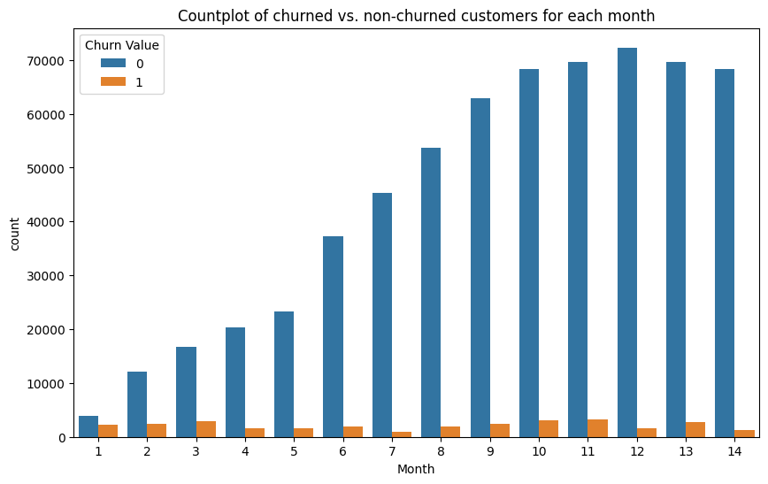

```python
# Plot the churn by month
plt.figure(figsize=(10,6))
sns.countplot(x="Month", hue="Churn Value", data=df)
plt.title("Countplot of churned vs. non-churned customers for each month")

churn_by_month = df.groupby('Month')['Churn Value'].mean()
print(churn_by_month)
```

**Observation**: